# Module 151

#### Contrast SVE:

Signed variance explained (SVE) provides an indication of how similar a set of fold changes are to a gene module’s weight vector. An SVE value of 0.3, for example, indicates that 30% of the variance explained by the entire module set is accounted for by the module in question. Shown here are the SVE values for this module across a compendium of fold changes (contrasts). Extreme SVE values (e.g., > 0.05) indicate that those contrasts specifically induce (orange dots) or specifically repress (blue dots) this module. Examining the experimental conditions being compared in such contrasts (see tables below the figure) may provide insight into the gene module’s function.

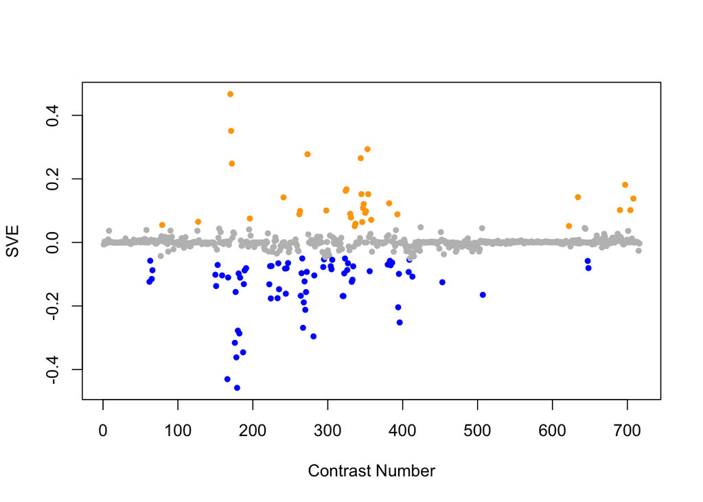

Positive SVE Contrasts:

|  | Contrast.Num | SVE | GEO.GSE | Cond.1 | Cond.2 | Mutation |
| --- | --- | --- | --- | --- | --- | --- |
| GSE47778.s4t3.vs.s2t3 | 170 | 0.47 | GSE47778 | daf-2;daf-16; UV; replicate 1 | daf-2; UV; replicate 1 | daf-2;daf-16 vs. daf-2 |
| GSE47778.s1t3.vs.s2t3 | 171 | 0.35 | GSE47778 | N2; UV; replicate 1 | daf-2; UV; replicate 1 | daf-2 |
| GSE38997.s4t3.vs.s4t1 | 353 | 0.29 | GSE38997 | experiment 1 UVC-exposed samples at 48 h 1u48 | experiment 4 UVC-exposed samples at 3 h 4u3 |  |
| GSE41366B.s2t1.vs.s0t1 | 273 | 0.28 | GSE41366 | high_DDVP-8h_expose-14h_harvest-rep1 | control-8h_expose-14h_harvest-rep1 |  |
| GSE38997.s1t3.vs.s1t1 | 344 | 0.27 | GSE38997 | experiment 1 control samples at 48 h 1c48 | experiment 4 control samples at 3 h 4c3 |  |
| GSE47778.s5t3.vs.s2t3 | 172 | 0.25 | GSE47778 | xpa-1 10mJ/cm2; replicate 1 | daf-2; UV; replicate 1 | xpa-1 vs. daf-2 |
| GSE11055.s1t8.vs.s2t8 | 697 | 0.18 | GSE11055 | L2 larvae 24 hr after hatching in the presence of food | L1 larvae 24 hr after hatching in the absence of food |  |
| GSE38997.s4t3.vs.s3t3 | 325 | 0.17 | GSE38997 | experiment 1 UVC-exposed samples at 48 h 1u48 | experiment 1 UVC- and EtBr-exposed samples at 48 h 1eu48 |  |
| GSE38997.s4t3.vs.s2t3 | 324 | 0.16 | GSE38997 | experiment 1 UVC-exposed samples at 48 h 1u48 | experiment 1 EtBr-exposed samples at 48 h 1e48 |  |
| GSE38997.s1t4.vs.s1t1 | 345 | 0.15 | GSE38997 | experiment 1 control samples at 51 h 1c51 | experiment 4 control samples at 3 h 4c3 |  |
| GSE38997.s4t4.vs.s4t1 | 354 | 0.15 | GSE38997 | experiment 1 UVC-exposed samples at 51 h 1u51 | experiment 4 UVC-exposed samples at 3 h 4u3 |  |
| GSE19138.s1t1.vs.s0t1 | 634 | 0.14 | GSE19138 | ALG-1(-) 1 | WT1 | alg-1 |
| GSE42592C.s1t3.vs.s0t3 | 241 | 0.14 | GSE42592 | mercury_low_expose-8h_rep1 | mercury_control_expose-8h_rep1 |  |
| GSE11055.s1t8.vs.s1t1 | 708 | 0.14 | GSE11055 | L2 larvae 24 hr after hatching in the presence of food | embryo 2 hr before hatching |  |
| GSE34471.s1t2.vs.s1t1 | 382 | 0.12 | GSE34471 | 20uM-Exp1 | 4uM-Exp1 |  |
| GSE38997.s2t4.vs.s2t1 | 348 | 0.12 | GSE38997 | experiment 1 EtBr-exposed samples at 51 h 1e51 | experiment 4 EtBr-exposed samples at 3 h 4e3 |  |
| GSE38997.s2t3.vs.s2t1 | 347 | 0.11 | GSE38997 | experiment 1 EtBr-exposed samples at 48 h 1e48 | experiment 4 EtBr-exposed samples at 3 h 4e3 |  |
| GSE11055.s1t6.vs.s2t6 | 690 | 0.10 | GSE11055 | L1 larvae 12 hr after hatching in the presence of food | L1 larvae 12 hr after hatching in the absence of food |  |
| GSE11055.s1t6.vs.s1t1 | 704 | 0.10 | GSE11055 | L1 larvae 12 hr after hatching in the presence of food | embryo 2 hr before hatching |  |
| GSE41366C.s0t2.vs.s0t1 | 298 | 0.10 | GSE41366 | control-continuous_expose-2h_harvest-rep1 | control-continuous_expose-0h_harvest-rep2 |  |
| GSE41366A.s1t1.vs.s0t1 | 263 | 0.10 | GSE41366 | low_DDVP-2h_expose-8h_harvest-rep1 | control-2h_expose-8h_harvest-rep1 |  |
| GSE38997.s3t4.vs.s3t1 | 351 | 0.10 | GSE38997 | experiment 1 UVC- and EtBr-exposed samples at 51 h 1eu51 | experiment 4 UVC- and EtBr-exposed samples at 3 h 4eu3 |  |
| GSE38997.s3t3.vs.s3t1 | 350 | 0.09 | GSE38997 | experiment 1 UVC- and EtBr-exposed samples at 48 h 1eu48 | experiment 4 UVC- and EtBr-exposed samples at 3 h 4eu3 |  |
| GSE38997.s4t4.vs.s2t4 | 330 | 0.09 | GSE38997 | experiment 1 UVC-exposed samples at 51 h 1u51 | experiment 1 EtBr-exposed samples at 51 h 1e51 |  |
| GSE41366A.s2t1.vs.s0t1 | 262 | 0.09 | GSE41366 | high_DDVP-2h_expose-8h_harvest-rep1 | control-2h_expose-8h_harvest-rep1 |  |
| GSE32339.s1t1.vs.s0t1 | 393 | 0.09 | GSE32339 | Larval Mutant, biological rep1 | Larval Wild-type, biological rep1 | nep-1 |
| GSE38997.s4t4.vs.s3t4 | 331 | 0.08 | GSE38997 | experiment 1 UVC-exposed samples at 51 h 1u51 | experiment 1 UVC- and EtBr-exposed samples at 51 h 1eu51 |  |
| GSE43959.s1t1.vs.s3t1 | 196 | 0.08 | GSE43959 | N2 young adult on E. coli OP50 rep 1 | N2 young adult on Comamonas DA1877 rep 1 |  |
| GSE38196.s1t2.vs.s1t1 | 358 | 0.07 | GSE38196 | atfs-1(tm4525)-treated, biological rep1 | atfs-1(tm4525)-control, biological rep1 | spg-7(RNAi) |
| GSE54011.s2t1.vs.s0t1 | 127 | 0.06 | GSE54011 | Ce 0.1 mM Se | Ce 0 mM Se |  |
| GSE38997.s1t2.vs.s1t1 | 346 | 0.06 | GSE38997 | experiment 4 control samples at 24 h 4c24 | experiment 4 control samples at 3 h 4c3 |  |
| GSE38997.s4t2.vs.s3t2 | 337 | 0.06 | GSE38997 | experiment 4 UVC-exposed samples at 24 h 4u24 | experiment 4 UVC- and EtBr-exposed samples at 24 h 4eu24 |  |
| GSE8004.s2t2.vs.s3t2 | 79 | 0.05 | GSE8004 | Larval Reference, biological rep 1 of set 1 | Larval Pan-neural, biological rep 1 of set 2 |  |
| GSE21162.s1t1.vs.s0t1 | 622 | 0.05 | GSE21162 | PVD and OLL neurons, biological rep1 | L3/L4 stage whole animal reference, rep1 |  |
| GSE38997.s4t2.vs.s2t2 | 336 | 0.05 | GSE38997 | experiment 4 UVC-exposed samples at 24 h 4u24 | experiment 4 EtBr-exposed samples at 24 h 4e24 |  |

Negative SVE Contrasts:

|  | Contrast.Num | SVE | GEO.GSE | Cond.1 | Cond.2 | Mutation |
| --- | --- | --- | --- | --- | --- | --- |
| GSE47778.s2t3.vs.s2t1 | 179 | -0.46 | GSE47778 | daf-2; UV; replicate 1 | daf-2; replicate 1 |  |
| GSE47778.s2t3.vs.s3t3 | 166 | -0.43 | GSE47778 | daf-2; UV; replicate 1 | daf-16; UV; replicate 1 | daf-2 vs. daf-16 |
| GSE47778.s2t2.vs.s2t1 | 178 | -0.36 | GSE47778 | daf-2; starvation; replicate 1 | daf-2; replicate 1 |  |
| GSE46291.s2t2.vs.s1t2 | 187 | -0.35 | GSE46291 | L4-lethargus_rep1 | L4_rep1 |  |
| GSE47778.s3t2.vs.s3t1 | 176 | -0.32 | GSE47778 | daf-16; starvation; replicate 1 | daf-16; replicate 1 |  |
| GSE41366B.s2t2.vs.s2t1 | 281 | -0.30 | GSE41366 | high_DDVP-8h_expose-20h_harvest-rep1 | high_DDVP-8h_expose-14h_harvest-rep1 |  |
| GSE47778.s1t2.vs.s1t1 | 182 | -0.29 | GSE47778 | N2; starvation; replicate 1 | N2; replicate 1 |  |
| GSE47778.s4t2.vs.s4t1 | 180 | -0.28 | GSE47778 | daf-2;daf-16; starvation; replicate 1 | daf-2;daf-16; replicate 1 |  |
| GSE41366A.s2t2.vs.s2t1 | 267 | -0.27 | GSE41366 | high_DDVP-2h_expose-14h_harvest-rep1 | high_DDVP-2h_expose-8h_harvest-rep1 |  |
| GSE32031.s1t1.vs.s0t1 | 396 | -0.25 | GSE32031 | Exerimental (nhr-23 RNAi), biological rep1 | Control, biological rep1 | nhr-23 |
| GSE41366A.s1t2.vs.s1t1 | 270 | -0.21 | GSE41366 | low_DDVP-2h_expose-14h_harvest-rep1 | low_DDVP-2h_expose-8h_harvest-rep1 |  |
| GSE32339.s1t2.vs.s1t1 | 394 | -0.20 | GSE32339 | Adult Mutant, biological rep1 | Larval Mutant, biological rep1 |  |
| GSE41366A.s2t3.vs.s2t1 | 268 | -0.19 | GSE41366 | high_DDVP-2h_expose-20h_harvest-rep1 | high_DDVP-2h_expose-8h_harvest-rep1 |  |
| GSE42592A.s1t3.vs.s1t2 | 224 | -0.18 | GSE42592 | acrylamide_low_expose-8h_rep1 | acrylamide_low_expose-4h_rep1 |  |
| GSE42592B.s0t3.vs.s0t1 | 233 | -0.18 | GSE42592 | cadmium_control_expose-8h_rep1 | cadmium_control_expose-0h_rep1 |  |
| GSE38997.s3t3.vs.s1t3 | 321 | -0.17 | GSE38997 | experiment 1 UVC- and EtBr-exposed samples at 48 h 1eu48 | experiment 1 control samples at 48 h 1c48 |  |
| GSE38997.s2t3.vs.s1t3 | 320 | -0.17 | GSE38997 | experiment 1 EtBr-exposed samples at 48 h 1e48 | experiment 1 control samples at 48 h 1c48 |  |
| GSE41366A.s0t2.vs.s0t1 | 264 | -0.17 | GSE41366 | control-2h_expose-14h_harvest-rep1 | control-2h_expose-8h_harvest-rep1 |  |
| GSE2210.s2t1.vs.s0t1 | 507 | -0.16 | GSE2210 | unc-43(n1186) Sample 1 | Wild type Sample 1 | unc-43 |
| GSE42592C.s0t3.vs.s0t1 | 244 | -0.16 | GSE42592 | mercury_control_expose-8h_rep1 | mercury_control_expose-0h_rep1 |  |
| GSE41366A.s1t3.vs.s1t1 | 271 | -0.16 | GSE41366 | low_DDVP-2h_expose-20h_harvest-rep1 | low_DDVP-2h_expose-8h_harvest-rep1 |  |
| GSE47778.s3t3.vs.s3t1 | 177 | -0.16 | GSE47778 | daf-16; UV; replicate 1 | daf-16; replicate 1 |  |
| GSE42592B.s1t3.vs.s1t2 | 235 | -0.15 | GSE42592 | cadmium_low_expose-8h_rep1 | cadmium_low_expose-4h_rep1 |  |
| GSE47778.s4t1.vs.s3t1 | 151 | -0.14 | GSE47778 | daf-2;daf-16; replicate 1 | daf-16; replicate 1 | daf-2;daf-16 vs. daf-16 |
| GSE42592A.s0t3.vs.s0t1 | 222 | -0.13 | GSE42592 | acrylamide_control_expose-8h_rep1 | acrylamide_control_expose-0h_rep1 |  |
| GSE46291.s2t1.vs.s1t1 | 188 | -0.13 | GSE46291 | L3-lethargus_rep1 | L3_rep1 |  |
| GSE25513.s3t1.vs.s0t1 | 453 | -0.13 | GSE25513 | aak-2 o/e (1) | WT (1) | aak-2 |
| GSE38997.s2t2.vs.s1t2 | 332 | -0.12 | GSE38997 | experiment 4 EtBr-exposed samples at 24 h 4e24 | experiment 4 control samples at 24 h 4c24 |  |
| GSE8696.s1t1.vs.s2t1 | 62 | -0.12 | GSE8696 | 4 uM hemin (4A) | 20 uM hemin (20A) |  |
| GSE41366A.s2t4.vs.s2t1 | 269 | -0.12 | GSE41366 | high_DDVP-2h_expose-26h_harvest-rep1 | high_DDVP-2h_expose-8h_harvest-rep1 |  |
| GSE38997.s3t2.vs.s1t2 | 333 | -0.12 | GSE38997 | experiment 4 UVC- and EtBr-exposed samples at 24 h 4eu24 | experiment 4 control samples at 24 h 4c24 |  |
| GSE8659.s2t1.vs.s1t1 | 65 | -0.11 | GSE8659 | strain GR1373 replicate 1 | N2 replicate 1 | eri-1 |
| GSE47778.s1t3.vs.s1t1 | 183 | -0.11 | GSE47778 | N2; UV; replicate 1 | N2; replicate 1 |  |
| GSE47778.s4t3.vs.s3t3 | 167 | -0.11 | GSE47778 | daf-2;daf-16; UV; replicate 1 | daf-16; UV; replicate 1 | daf-2;daf-16 vs. daf-16 |
| GSE29951.s1t2.vs.s0t2 | 413 | -0.11 | GSE29951 | C.elegans MT KO mtl-1,mtl-2(zs1) raised in the presence of Cd, rep1 | C.elegans wild type raised in the presence of Cd, rep1 | mtl-1;mtl-2 |
| GSE41366B.s2t3.vs.s2t1 | 282 | -0.10 | GSE41366 | high_DDVP-8h_expose-26h_harvest-rep1 | high_DDVP-8h_expose-14h_harvest-rep1 |  |
| GSE47778.s5t1.vs.s1t1 | 159 | -0.10 | GSE47778 | xpa-1 0mJ/cm2; replicate 1 | N2; replicate 1 | xpa-1 |
| GSE47778.s2t1.vs.s3t1 | 150 | -0.10 | GSE47778 | daf-2; replicate 1 | daf-16; replicate 1 | daf-2 vs. daf-16 |
| GSE32339.s0t2.vs.s0t1 | 395 | -0.10 | GSE32339 | Adult Wild-type, biological rep1 | Larval Wild-type, biological rep1 |  |
| GSE47778.s4t3.vs.s4t1 | 181 | -0.10 | GSE47778 | daf-2;daf-16; UV; replicate 1 | daf-2;daf-16; replicate 1 |  |
| GSE38997.s4t3.vs.s1t3 | 322 | -0.10 | GSE38997 | experiment 1 UVC-exposed samples at 48 h 1u48 | experiment 1 control samples at 48 h 1c48 |  |
| GSE41366A.s0t3.vs.s0t1 | 265 | -0.10 | GSE41366 | control-2h_expose-20h_harvest-rep1 | control-2h_expose-8h_harvest-rep1 |  |
| GSE30505.s1t1.vs.s2t1 | 408 | -0.09 | GSE30505 | L3 N2 (WT) E.V. #1 | L3 N2 (WT) ash-2 #1 | ash-2 |
| GSE41366A.s1t4.vs.s1t1 | 272 | -0.09 | GSE41366 | low_DDVP-2h_expose-26h_harvest-rep1 | low_DDVP-2h_expose-8h_harvest-rep1 |  |
| GSE38196.s1t1.vs.s0t1 | 356 | -0.09 | GSE38196 | atfs-1(tm4525)-control, biological rep1 | wild-type-control, biological rep1 | afts-1 |
| GSE46291.s1t3.vs.s1t1 | 189 | -0.09 | GSE46291 | Adult_rep1 | L3_rep1 |  |
| GSE8659.s3t1.vs.s1t1 | 66 | -0.09 | GSE8659 | strain NL 2099 replicate 2 | N2 replicate 1 | rrf-3 |
| GSE38997.s2t4.vs.s1t4 | 326 | -0.09 | GSE38997 | experiment 1 EtBr-exposed samples at 51 h 1e51 | experiment 1 control samples at 51 h 1c51 |  |
| GSE41366C.s1t4.vs.s1t1 | 305 | -0.08 | GSE41366 | low_DDVP-continuous_expose-20h_harvest-rep1 | low_DDVP-continuous_expose-2h_harvest-rep1 |  |
| GSE42592C.s0t2.vs.s0t1 | 243 | -0.08 | GSE42592 | mercury_control_expose-4h_rep1 | mercury_control_expose-0h_rep1 |  |
| GSE42592C.s3t3.vs.s3t2 | 245 | -0.08 | GSE42592 | mercury_high_expose-8h_rep1 | mercury_high_expose-4h_rep1 |  |
| GSE46291.s2t2.vs.s2t1 | 191 | -0.08 | GSE46291 | L4-lethargus_rep1 | L3-lethargus_rep1 |  |
| GSE16753.s1t1.vs.s0t1 | 648 | -0.08 | GSE16753 | fer-1 (hc24ts) mutant young adult biological rep 1 | Wild-type young adult biological rep 3 | fer-1 |
| GSE41366C.s1t3.vs.s0t3 | 294 | -0.08 | GSE41366 | low_DDVP-continuous_expose-14h_harvest-rep1 | control-continuous_expose-8h_harvest-rep1 |  |
| GSE38997.s4t2.vs.s1t2 | 334 | -0.08 | GSE38997 | experiment 4 UVC-exposed samples at 24 h 4u24 | experiment 4 control samples at 24 h 4c24 |  |
| GSE41366C.s1t3.vs.s1t1 | 304 | -0.07 | GSE41366 | low_DDVP-continuous_expose-14h_harvest-rep1 | low_DDVP-continuous_expose-2h_harvest-rep1 |  |
| GSE42592A.s3t3.vs.s3t2 | 223 | -0.07 | GSE42592 | acrylamide_high_expose-8h_rep1 | acrylamide_high_expose-4h_rep1 |  |
| GSE42592A.s2t3.vs.s2t2 | 225 | -0.07 | GSE42592 | acrylamide_mid_expose-8h_rep1 | acrylamide_mid_expose-4h_rep1 |  |
| GSE34026.s4t1.vs.s0t1 | 384 | -0.07 | GSE34026 | N2 exposed to CVD109, biological rep1 | N2 exposed to OP50(E.coli), biological rep1 |  |
| GSE47778.s5t1.vs.s3t1 | 153 | -0.07 | GSE47778 | xpa-1 0mJ/cm2; replicate 1 | daf-16; replicate 1 | xpa-1 vs. daf-16 |
| GSE34471.s1t1.vs.s0t1 | 380 | -0.07 | GSE34471 | 4uM-Exp1 | 4uM-Con-1 | hrg-2 |
| GSE38997.s3t4.vs.s1t4 | 327 | -0.07 | GSE38997 | experiment 1 UVC- and EtBr-exposed samples at 51 h 1eu51 | experiment 1 control samples at 51 h 1c51 |  |
| GSE42592B.s3t3.vs.s3t2 | 234 | -0.07 | GSE42592 | cadmium_high_expose-8h_rep1 | cadmium_high_expose-4h_rep1 |  |
| GSE42592C.s2t3.vs.s2t2 | 247 | -0.06 | GSE42592 | mercury_mid_expose-8h_rep1 | mercury_mid_expose-4h_rep1 |  |
| GSE34026.s2t1.vs.s0t1 | 386 | -0.06 | GSE34026 | N2 exposed to E7946, biological rep1 | N2 exposed to OP50(E.coli), biological rep1 |  |
| GSE16753.s2t1.vs.s0t1 | 647 | -0.06 | GSE16753 | fer-1 (hc1ts) mutant young adult biological rep 1 | Wild-type young adult biological rep 3 | fer-1 |
| GSE34113.s1t1.vs.s0t1 | 383 | -0.06 | GSE34113 | tdp-1(ok803) | wild-type 1 | tdp-1 |
| GSE8696.s3t1.vs.s2t1 | 63 | -0.06 | GSE8696 | 500 uM hemin (500A) | 20 uM hemin (20A) |  |
| GSE41366C.s1t5.vs.s1t1 | 306 | -0.05 | GSE41366 | low_DDVP-continuous_expose-26h_harvest-rep1 | low_DDVP-continuous_expose-2h_harvest-rep1 |  |
| GSE30505.s4t2.vs.s4t1 | 409 | -0.05 | GSE30505 | Day 8 glp-1 ash-2 #1 | L3 glp-1 ash-2 #1 |  |
| GSE41366C.s0t4.vs.s0t1 | 295 | -0.05 | GSE41366 | control-continuous_expose-14h_harvest-rep1 | control-continuous_expose-0h_harvest-rep2 |  |
| GSE38997.s3t3.vs.s2t3 | 323 | -0.05 | GSE38997 | experiment 1 UVC- and EtBr-exposed samples at 48 h 1eu48 | experiment 1 EtBr-exposed samples at 48 h 1e48 |  |
| GSE41366A.s0t4.vs.s0t1 | 266 | -0.05 | GSE41366 | control-2h_expose-26h_harvest-rep1 | control-2h_expose-8h_harvest-rep1 |  |

$~$

#### Contrast SVE, Up-Regulated Genes Only:

Calculating SVE for up-regulated and down-regulated genes separately may be more informative in many cases than projecting the up- and down- gene sets together. This is due to the fact that the weight distribution of many modules is highly skewed, indicating that only one of the hemi-modules may be biologically meaningful (i.e., a set of genes are strongly correlated by only a few genes (or none) are strongly anti-correlated to that set.)

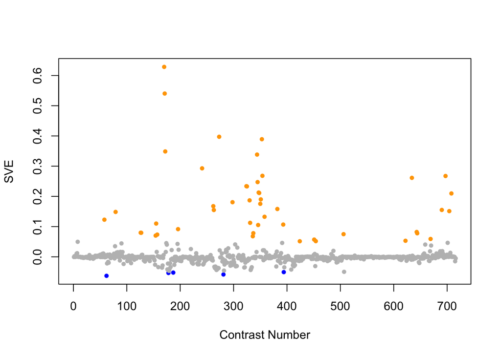

Positive SVE Contrasts:

|  | Contrast.Num | SVE | GEO.GSE | Cond.1 | Cond.2 | Mutation |
| --- | --- | --- | --- | --- | --- | --- |
| GSE47778.s4t3.vs.s2t3 | 170 | 0.63 | GSE47778 | daf-2;daf-16; UV; replicate 1 | daf-2; UV; replicate 1 | daf-2;daf-16 vs. daf-2 |
| GSE47778.s1t3.vs.s2t3 | 171 | 0.54 | GSE47778 | N2; UV; replicate 1 | daf-2; UV; replicate 1 | daf-2 |
| GSE41366B.s2t1.vs.s0t1 | 273 | 0.40 | GSE41366 | high_DDVP-8h_expose-14h_harvest-rep1 | control-8h_expose-14h_harvest-rep1 |  |
| GSE38997.s4t3.vs.s4t1 | 353 | 0.39 | GSE38997 | experiment 1 UVC-exposed samples at 48 h 1u48 | experiment 4 UVC-exposed samples at 3 h 4u3 |  |
| GSE47778.s5t3.vs.s2t3 | 172 | 0.35 | GSE47778 | xpa-1 10mJ/cm2; replicate 1 | daf-2; UV; replicate 1 | xpa-1 vs. daf-2 |
| GSE38997.s1t3.vs.s1t1 | 344 | 0.34 | GSE38997 | experiment 1 control samples at 48 h 1c48 | experiment 4 control samples at 3 h 4c3 |  |
| GSE42592C.s1t3.vs.s0t3 | 241 | 0.29 | GSE42592 | mercury_low_expose-8h_rep1 | mercury_control_expose-8h_rep1 |  |
| GSE38997.s4t4.vs.s4t1 | 354 | 0.27 | GSE38997 | experiment 1 UVC-exposed samples at 51 h 1u51 | experiment 4 UVC-exposed samples at 3 h 4u3 |  |
| GSE11055.s1t8.vs.s2t8 | 697 | 0.27 | GSE11055 | L2 larvae 24 hr after hatching in the presence of food | L1 larvae 24 hr after hatching in the absence of food |  |
| GSE19138.s1t1.vs.s0t1 | 634 | 0.26 | GSE19138 | ALG-1(-) 1 | WT1 | alg-1 |
| GSE38997.s1t4.vs.s1t1 | 345 | 0.25 | GSE38997 | experiment 1 control samples at 51 h 1c51 | experiment 4 control samples at 3 h 4c3 |  |
| GSE38997.s4t3.vs.s2t3 | 324 | 0.23 | GSE38997 | experiment 1 UVC-exposed samples at 48 h 1u48 | experiment 1 EtBr-exposed samples at 48 h 1e48 |  |
| GSE38997.s4t3.vs.s3t3 | 325 | 0.23 | GSE38997 | experiment 1 UVC-exposed samples at 48 h 1u48 | experiment 1 UVC- and EtBr-exposed samples at 48 h 1eu48 |  |
| GSE38997.s2t3.vs.s2t1 | 347 | 0.21 | GSE38997 | experiment 1 EtBr-exposed samples at 48 h 1e48 | experiment 4 EtBr-exposed samples at 3 h 4e3 |  |
| GSE38997.s2t4.vs.s2t1 | 348 | 0.21 | GSE38997 | experiment 1 EtBr-exposed samples at 51 h 1e51 | experiment 4 EtBr-exposed samples at 3 h 4e3 |  |
| GSE11055.s1t8.vs.s1t1 | 708 | 0.21 | GSE11055 | L2 larvae 24 hr after hatching in the presence of food | embryo 2 hr before hatching |  |
| GSE38997.s3t4.vs.s3t1 | 351 | 0.19 | GSE38997 | experiment 1 UVC- and EtBr-exposed samples at 51 h 1eu51 | experiment 4 UVC- and EtBr-exposed samples at 3 h 4eu3 |  |
| GSE38997.s4t4.vs.s2t4 | 330 | 0.19 | GSE38997 | experiment 1 UVC-exposed samples at 51 h 1u51 | experiment 1 EtBr-exposed samples at 51 h 1e51 |  |
| GSE41366C.s0t2.vs.s0t1 | 298 | 0.18 | GSE41366 | control-continuous_expose-2h_harvest-rep1 | control-continuous_expose-0h_harvest-rep2 |  |
| GSE38997.s3t3.vs.s3t1 | 350 | 0.18 | GSE38997 | experiment 1 UVC- and EtBr-exposed samples at 48 h 1eu48 | experiment 4 UVC- and EtBr-exposed samples at 3 h 4eu3 |  |
| GSE41366A.s2t1.vs.s0t1 | 262 | 0.17 | GSE41366 | high_DDVP-2h_expose-8h_harvest-rep1 | control-2h_expose-8h_harvest-rep1 |  |
| GSE34471.s1t2.vs.s1t1 | 382 | 0.16 | GSE34471 | 20uM-Exp1 | 4uM-Exp1 |  |
| GSE11055.s1t6.vs.s2t6 | 690 | 0.16 | GSE11055 | L1 larvae 12 hr after hatching in the presence of food | L1 larvae 12 hr after hatching in the absence of food |  |
| GSE41366A.s1t1.vs.s0t1 | 263 | 0.15 | GSE41366 | low_DDVP-2h_expose-8h_harvest-rep1 | control-2h_expose-8h_harvest-rep1 |  |
| GSE11055.s1t6.vs.s1t1 | 704 | 0.15 | GSE11055 | L1 larvae 12 hr after hatching in the presence of food | embryo 2 hr before hatching |  |
| GSE8004.s2t2.vs.s3t2 | 79 | 0.15 | GSE8004 | Larval Reference, biological rep 1 of set 1 | Larval Pan-neural, biological rep 1 of set 2 |  |
| GSE38196.s1t2.vs.s1t1 | 358 | 0.13 | GSE38196 | atfs-1(tm4525)-treated, biological rep1 | atfs-1(tm4525)-control, biological rep1 | spg-7(RNAi) |
| GSE9485.s2t1.vs.s1t1 | 58 | 0.12 | GSE9485 | Larval Reference, biological rep 1 | Larval Pan-neural, biological rep 1 |  |
| GSE38997.s4t4.vs.s3t4 | 331 | 0.11 | GSE38997 | experiment 1 UVC-exposed samples at 51 h 1u51 | experiment 1 UVC- and EtBr-exposed samples at 51 h 1eu51 |  |
| GSE47778.s1t1.vs.s2t1 | 155 | 0.11 | GSE47778 | N2; replicate 1 | daf-2; replicate 1 | daf-2 |
| GSE32339.s1t1.vs.s0t1 | 393 | 0.11 | GSE32339 | Larval Mutant, biological rep1 | Larval Wild-type, biological rep1 | nep-1 |
| GSE38997.s1t2.vs.s1t1 | 346 | 0.11 | GSE38997 | experiment 4 control samples at 24 h 4c24 | experiment 4 control samples at 3 h 4c3 |  |
| GSE43959.s1t1.vs.s3t1 | 196 | 0.09 | GSE43959 | N2 young adult on E. coli OP50 rep 1 | N2 young adult on Comamonas DA1877 rep 1 |  |
| GSE16975.s1t1.vs.s0t1 | 643 | 0.08 | GSE16975 | C.elegans hydrogen sulfide sample replicate 1 | C.elegans control sample replicate 1 |  |
| GSE54011.s1t1.vs.s0t1 | 126 | 0.08 | GSE54011 | Ce 0.05 mM Se | Ce 0 mM Se |  |
| GSE54011.s2t1.vs.s0t1 | 127 | 0.08 | GSE54011 | Ce 0.1 mM Se | Ce 0 mM Se |  |
| GSE38997.s4t2.vs.s3t2 | 337 | 0.08 | GSE38997 | experiment 4 UVC-exposed samples at 24 h 4u24 | experiment 4 UVC- and EtBr-exposed samples at 24 h 4eu24 |  |
| GSE16915.s1t1.vs.s3t1 | 644 | 0.08 | GSE16915 | control sample | bio-electrosprayed sample |  |
| GSE2210.s1t1.vs.s0t1 | 506 | 0.07 | GSE2210 | tom-1(nu468) Sample 1 | Wild type Sample 1 | tom-1 |
| GSE47778.s1t1.vs.s4t1 | 157 | 0.07 | GSE47778 | N2; replicate 1 | daf-2;daf-16; replicate 1 | daf-2;daf-16 |
| GSE47778.s4t1.vs.s2t1 | 154 | 0.07 | GSE47778 | daf-2;daf-16; replicate 1 | daf-2; replicate 1 | daf-2;daf-16 vs. daf-2 |
| GSE38997.s4t2.vs.s2t2 | 336 | 0.07 | GSE38997 | experiment 4 UVC-exposed samples at 24 h 4u24 | experiment 4 EtBr-exposed samples at 24 h 4e24 |  |
| GSE15016.s3t1.vs.s0t1 | 669 | 0.06 | GSE15016 | young adult_24hr DEHP exposure_rep1 | young adult_not exposured_rep1 |  |
| GSE25633.s1t1.vs.s3t1 | 451 | 0.06 | GSE25633 | WT#1 | daf-12#1 | daf-12 |
| GSE21162.s1t1.vs.s0t1 | 622 | 0.05 | GSE21162 | PVD and OLL neurons, biological rep1 | L3/L4 stage whole animal reference, rep1 |  |
| GSE25513.s2t1.vs.s0t1 | 454 | 0.05 | GSE25513 | crh-1 null (1) | WT (1) | crh-1 |
| GSE27867.s1t1.vs.s0t1 | 424 | 0.05 | GSE27867 | tag-24, biological rep1 | wt, biological rep1 | tag-24 |

Negative SVE Contrasts:

|  | Contrast.Num | SVE | GEO.GSE | Cond.1 | Cond.2 | Mutation |
| --- | --- | --- | --- | --- | --- | --- |
| GSE8696.s1t1.vs.s2t1 | 62 | -0.06 | GSE8696 | 4 uM hemin (4A) | 20 uM hemin (20A) |  |
| GSE41366B.s2t2.vs.s2t1 | 281 | -0.06 | GSE41366 | high_DDVP-8h_expose-20h_harvest-rep1 | high_DDVP-8h_expose-14h_harvest-rep1 |  |
| GSE47778.s2t2.vs.s2t1 | 178 | -0.05 | GSE47778 | daf-2; starvation; replicate 1 | daf-2; replicate 1 |  |
| GSE46291.s2t2.vs.s1t2 | 187 | -0.05 | GSE46291 | L4-lethargus_rep1 | L4_rep1 |  |
| GSE32339.s1t2.vs.s1t1 | 394 | -0.05 | GSE32339 | Adult Mutant, biological rep1 | Larval Mutant, biological rep1 |  |

$~$

#### Contrast SVE, Down-Regulated Genes Only:

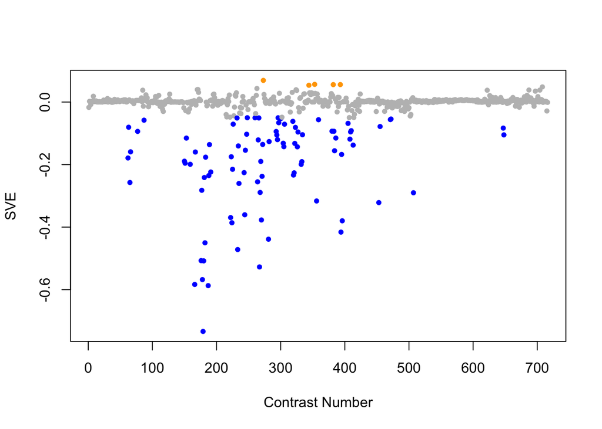

Positive SVE Contrasts:

|  | Contrast.Num | SVE | GEO.GSE | Cond.1 | Cond.2 | Mutation |
| --- | --- | --- | --- | --- | --- | --- |
| GSE41366B.s2t1.vs.s0t1 | 273 | 0.07 | GSE41366 | high_DDVP-8h_expose-14h_harvest-rep1 | control-8h_expose-14h_harvest-rep1 |  |
| GSE38997.s4t3.vs.s4t1 | 353 | 0.06 | GSE38997 | experiment 1 UVC-exposed samples at 48 h 1u48 | experiment 4 UVC-exposed samples at 3 h 4u3 |  |
| GSE32339.s1t1.vs.s0t1 | 393 | 0.06 | GSE32339 | Larval Mutant, biological rep1 | Larval Wild-type, biological rep1 | nep-1 |
| GSE34471.s1t2.vs.s1t1 | 382 | 0.06 | GSE34471 | 20uM-Exp1 | 4uM-Exp1 |  |
| GSE38997.s1t3.vs.s1t1 | 344 | 0.05 | GSE38997 | experiment 1 control samples at 48 h 1c48 | experiment 4 control samples at 3 h 4c3 |  |

Negative SVE Contrasts:

|  | Contrast.Num | SVE | GEO.GSE | Cond.1 | Cond.2 | Mutation |
| --- | --- | --- | --- | --- | --- | --- |
| GSE47778.s2t3.vs.s2t1 | 179 | -0.73 | GSE47778 | daf-2; UV; replicate 1 | daf-2; replicate 1 |  |
| GSE46291.s2t2.vs.s1t2 | 187 | -0.59 | GSE46291 | L4-lethargus_rep1 | L4_rep1 |  |
| GSE47778.s2t3.vs.s3t3 | 166 | -0.58 | GSE47778 | daf-2; UV; replicate 1 | daf-16; UV; replicate 1 | daf-2 vs. daf-16 |
| GSE47778.s2t2.vs.s2t1 | 178 | -0.57 | GSE47778 | daf-2; starvation; replicate 1 | daf-2; replicate 1 |  |
| GSE41366A.s2t2.vs.s2t1 | 267 | -0.53 | GSE41366 | high_DDVP-2h_expose-14h_harvest-rep1 | high_DDVP-2h_expose-8h_harvest-rep1 |  |
| GSE47778.s4t2.vs.s4t1 | 180 | -0.51 | GSE47778 | daf-2;daf-16; starvation; replicate 1 | daf-2;daf-16; replicate 1 |  |
| GSE47778.s3t2.vs.s3t1 | 176 | -0.51 | GSE47778 | daf-16; starvation; replicate 1 | daf-16; replicate 1 |  |
| GSE42592B.s0t3.vs.s0t1 | 233 | -0.47 | GSE42592 | cadmium_control_expose-8h_rep1 | cadmium_control_expose-0h_rep1 |  |
| GSE47778.s1t2.vs.s1t1 | 182 | -0.45 | GSE47778 | N2; starvation; replicate 1 | N2; replicate 1 |  |
| GSE41366B.s2t2.vs.s2t1 | 281 | -0.44 | GSE41366 | high_DDVP-8h_expose-20h_harvest-rep1 | high_DDVP-8h_expose-14h_harvest-rep1 |  |
| GSE32339.s1t2.vs.s1t1 | 394 | -0.42 | GSE32339 | Adult Mutant, biological rep1 | Larval Mutant, biological rep1 |  |
| GSE42592A.s1t3.vs.s1t2 | 224 | -0.39 | GSE42592 | acrylamide_low_expose-8h_rep1 | acrylamide_low_expose-4h_rep1 |  |
| GSE32031.s1t1.vs.s0t1 | 396 | -0.38 | GSE32031 | Exerimental (nhr-23 RNAi), biological rep1 | Control, biological rep1 | nhr-23 |
| GSE41366A.s1t2.vs.s1t1 | 270 | -0.38 | GSE41366 | low_DDVP-2h_expose-14h_harvest-rep1 | low_DDVP-2h_expose-8h_harvest-rep1 |  |
| GSE42592A.s0t3.vs.s0t1 | 222 | -0.37 | GSE42592 | acrylamide_control_expose-8h_rep1 | acrylamide_control_expose-0h_rep1 |  |
| GSE42592C.s0t3.vs.s0t1 | 244 | -0.36 | GSE42592 | mercury_control_expose-8h_rep1 | mercury_control_expose-0h_rep1 |  |
| GSE25513.s3t1.vs.s0t1 | 453 | -0.32 | GSE25513 | aak-2 o/e (1) | WT (1) | aak-2 |
| GSE38196.s1t1.vs.s0t1 | 356 | -0.32 | GSE38196 | atfs-1(tm4525)-control, biological rep1 | wild-type-control, biological rep1 | afts-1 |
| GSE2210.s2t1.vs.s0t1 | 507 | -0.29 | GSE2210 | unc-43(n1186) Sample 1 | Wild type Sample 1 | unc-43 |
| GSE41366A.s2t3.vs.s2t1 | 268 | -0.29 | GSE41366 | high_DDVP-2h_expose-20h_harvest-rep1 | high_DDVP-2h_expose-8h_harvest-rep1 |  |
| GSE47778.s3t3.vs.s3t1 | 177 | -0.28 | GSE47778 | daf-16; UV; replicate 1 | daf-16; replicate 1 |  |
| GSE42592B.s1t3.vs.s1t2 | 235 | -0.26 | GSE42592 | cadmium_low_expose-8h_rep1 | cadmium_low_expose-4h_rep1 |  |
| GSE8659.s2t1.vs.s1t1 | 65 | -0.26 | GSE8659 | strain GR1373 replicate 1 | N2 replicate 1 | eri-1 |
| GSE41366A.s0t2.vs.s0t1 | 264 | -0.26 | GSE41366 | control-2h_expose-14h_harvest-rep1 | control-2h_expose-8h_harvest-rep1 |  |
| GSE47778.s4t3.vs.s4t1 | 181 | -0.24 | GSE47778 | daf-2;daf-16; UV; replicate 1 | daf-2;daf-16; replicate 1 |  |
| GSE41366A.s1t3.vs.s1t1 | 271 | -0.24 | GSE41366 | low_DDVP-2h_expose-20h_harvest-rep1 | low_DDVP-2h_expose-8h_harvest-rep1 |  |
| GSE46291.s2t1.vs.s1t1 | 188 | -0.24 | GSE46291 | L3-lethargus_rep1 | L3_rep1 |  |
| GSE38997.s2t3.vs.s1t3 | 320 | -0.23 | GSE38997 | experiment 1 EtBr-exposed samples at 48 h 1e48 | experiment 1 control samples at 48 h 1c48 |  |
| GSE38997.s3t3.vs.s1t3 | 321 | -0.23 | GSE38997 | experiment 1 UVC- and EtBr-exposed samples at 48 h 1eu48 | experiment 1 control samples at 48 h 1c48 |  |
| GSE42592C.s0t2.vs.s0t1 | 243 | -0.23 | GSE42592 | mercury_control_expose-4h_rep1 | mercury_control_expose-0h_rep1 |  |

[output cut: 61 more lines]

$~$

$~$

#### GO Term Enrichment:

This analysis tests each hemi-module for enrichment of specific GO terms. Only gene-level annotations (e.g., as would be found on the gene’s page in Wormbase) are tested - the hierarchical structure of the GO ontology is not taken into account.

*Note: At least the top two most enriched terms from each GO domain (BP/MF/CC) are shown, even when not statistically significant.*

##### Enriched GO terms: Hemi-module A

| ID | GO.Term | GO Domain | Raw p-value | Adj p-value |
| --- | --- | --- | --- | --- |
| [GO_0042338](http://amigo.geneontology.org/amigo/term/GO:0042338) | cuticle development involved in collagen and cuticulin-based cuticle molting cycle | BP | 3.75e-12 | 1.37e-08 |
| [GO_0018996](http://amigo.geneontology.org/amigo/term/GO:0018996) | molting cycle, collagen and cuticulin-based cuticle | BP | 1.70e-11 | 3.09e-08 |
| [GO_0010951](http://amigo.geneontology.org/amigo/term/GO:0010951) | negative regulation of endopeptidase activity | BP | 8.94e-07 | 1.09e-03 |
| [GO_0045454](http://amigo.geneontology.org/amigo/term/GO:0045454) | cell redox homeostasis | BP | 3.67e-06 | 3.34e-03 |
| [GO_0007186](http://amigo.geneontology.org/amigo/term/GO:0007186) | G protein-coupled receptor signaling pathway | BP | 5.22e-06 | 3.80e-03 |
| [GO_0008643](http://amigo.geneontology.org/amigo/term/GO:0008643) | carbohydrate transport | BP | 1.09e-04 | 6.30e-02 |
| [GO_0007156](http://amigo.geneontology.org/amigo/term/GO:0007156) | homophilic cell adhesion via plasma membrane adhesion molecules | BP | 1.38e-04 | 6.30e-02 |
| [GO_0040002](http://amigo.geneontology.org/amigo/term/GO:0040002) | collagen and cuticulin-based cuticle development | BP | 1.38e-04 | 6.30e-02 |
| [GO_0042329](http://amigo.geneontology.org/amigo/term/GO:0042329) | structural constituent of collagen and cuticulin-based cuticle | MF | 1.40e-07 | 1.51e-04 |
| [GO_0004867](http://amigo.geneontology.org/amigo/term/GO:0004867) | serine-type endopeptidase inhibitor activity | MF | 1.48e-07 | 1.51e-04 |
| [GO_0042302](http://amigo.geneontology.org/amigo/term/GO:0042302) | structural constituent of cuticle | MF | 5.38e-07 | 3.66e-04 |
| [GO_0016757](http://amigo.geneontology.org/amigo/term/GO:0016757) | transferase activity, transferring glycosyl groups | MF | 6.46e-06 | 3.30e-03 |
| [GO_0003756](http://amigo.geneontology.org/amigo/term/GO:0003756) | protein disulfide isomerase activity | MF | 5.86e-05 | 2.40e-02 |
| [GO_0016853](http://amigo.geneontology.org/amigo/term/GO:0016853) | isomerase activity | MF | 1.44e-04 | 4.90e-02 |
| [GO_0005509](http://amigo.geneontology.org/amigo/term/GO:0005509) | calcium ion binding | MF | 1.75e-04 | 5.12e-02 |
| [GO_0005576](http://amigo.geneontology.org/amigo/term/GO:0005576) | extracellular region | CC | 5.83e-08 | 5.41e-05 |
| [GO_0005788](http://amigo.geneontology.org/amigo/term/GO:0005788) | endoplasmic reticulum lumen | CC | 3.48e-07 | 1.62e-04 |
| [GO_0060102](http://amigo.geneontology.org/amigo/term/GO:0060102) | collagen and cuticulin-based cuticle extracellular matrix | CC | 1.12e-06 | 2.64e-04 |
| [GO_0005634](http://amigo.geneontology.org/amigo/term/GO:0005634) | nucleus | CC | 1.14e-06 | 2.64e-04 |
| [GO_0005615](http://amigo.geneontology.org/amigo/term/GO:0005615) | extracellular space | CC | 1.98e-06 | 3.68e-04 |
| [GO_0005581](http://amigo.geneontology.org/amigo/term/GO:0005581) | collagen trimer | CC | 7.07e-06 | 1.09e-03 |
| [GO_0016021](http://amigo.geneontology.org/amigo/term/GO:0016021) | integral component of membrane | CC | 1.09e-05 | 1.45e-03 |
| [GO_0016020](http://amigo.geneontology.org/amigo/term/GO:0016020) | membrane | CC | 1.45e-05 | 1.68e-03 |
| [GO_0005783](http://amigo.geneontology.org/amigo/term/GO:0005783) | endoplasmic reticulum | CC | 2.52e-04 | 2.60e-02 |

##### Enriched GO terms: Hemi-module B

| ID | GO.Term | GO Domain | Raw p-value | Adj p-value |
| --- | --- | --- | --- | --- |
| [GO_0008283](http://amigo.geneontology.org/amigo/term/GO:0008283) | cell proliferation | BP | 1.99e-03 | 1.00e+00 |
| [GO_0019442](http://amigo.geneontology.org/amigo/term/GO:0019442) | tryptophan catabolic process to acetyl-CoA | BP | 1.99e-03 | 1.00e+00 |
| [GO_0004181](http://amigo.geneontology.org/amigo/term/GO:0004181) | metallocarboxypeptidase activity | MF | 3.94e-04 | 8.05e-01 |
| [GO_0004833](http://amigo.geneontology.org/amigo/term/GO:0004833) | tryptophan 2,3-dioxygenase activity | MF | 1.99e-03 | 1.00e+00 |
| [GO_0005615](http://amigo.geneontology.org/amigo/term/GO:0005615) | extracellular space | CC | 1.18e-05 | 1.10e-02 |
| [GO_0098733](http://amigo.geneontology.org/amigo/term/GO:0098733) | hemidesmosome associated protein complex | CC | 1.99e-03 | 9.26e-01 |

$~$

$~$

#### Tissue Enrichment:

This analysis tests each hemi-module for enrichment of genes associated with anatomy terms. Negative enrichment scores indicate fewer hemi-module genes than expected by random chance were associated with the anatomy term in question.

##### Enriched tissues: Hemi-module A

| ID | Anatomy.Term | Definition | Raw p-value | Adj p-value |
| --- | --- | --- | --- | --- |
| [WBbt_0005753](https://wormbase.org/species/all/anatomy_term/WBbt:0005753) | seam cell | a group of hypodermal cells that lie along the apical midline of the hypodermis, at the extreme left and right sides between nose and tail | 7.35e-15 | 1.79e-11 |
| [WBbt_0005733](https://wormbase.org/species/all/anatomy_term/WBbt:0005733) | hypodermis | Epidermal layer. | 6.09e-12 | 7.41e-09 |
| [WBbt_0005778](https://wormbase.org/species/all/anatomy_term/WBbt:0005778) | excretory pore | The outlet of the excretory sinus to the exterior environment through the cuticle, on the ventral side of the head, just behind the nerve ring. | 2.21e-10 | 1.79e-07 |
| [WBbt_0005734](https://wormbase.org/species/all/anatomy_term/WBbt:0005734) | hyp7 syncytium | entire syncytium of hyp7 | 3.38e-10 | 2.06e-07 |
| [WBbt_0005777](https://wormbase.org/species/all/anatomy_term/WBbt:0005777) | Excretory duct | The extracellular sinus formed by the excretory duct and pore cells. | 2.34e-06 | 1.14e-03 |
| [WBbt_0004540](https://wormbase.org/species/all/anatomy_term/WBbt:0004540) | excretory duct cell | cell that forms the duct of the excretory system. | 3.20e-06 | 1.30e-03 |
| [WBbt_0003929](https://wormbase.org/species/all/anatomy_term/WBbt:0003929) | AMsoR | Amphid socket cell, right | 1.06e-05 | 3.21e-03 |
| [WBbt_0003931](https://wormbase.org/species/all/anatomy_term/WBbt:0003931) | AMsoL | Amphid socket cell, left | 1.06e-05 | 3.21e-03 |
| [WBbt_0006762](https://wormbase.org/species/all/anatomy_term/WBbt:0006762) | vulA | adult vulval toroid cell, A, formed by fusion of precursors of lineage names P5.paaa, P5.paap, P7.pppa and P7.pppp | 1.95e-05 | 5.27e-03 |
| [WBbt_0004679](https://wormbase.org/species/all/anatomy_term/WBbt:0004679) | hyp6 | Cylindrical hypodermal syncytium in head | 4.31e-05 | 9.52e-03 |
| [WBbt_0004942](https://wormbase.org/species/all/anatomy_term/WBbt:0004942) | U cell | Rectal cell, postembryonic blast cell in male | 4.45e-05 | 9.52e-03 |
| [WBbt_0004378](https://wormbase.org/species/all/anatomy_term/WBbt:0004378) | hyp10 | Tail ventral hypodermis | 4.70e-05 | 9.52e-03 |
| [WBbt_0006765](https://wormbase.org/species/all/anatomy_term/WBbt:0006765) | vulC | adult vulval toroid cell, C, formed by fusion of precursors of lineage names P5.ppal, P5.ppar, P7.papl and P7.papr. | 5.92e-05 | 1.11e-02 |
| [WBbt_0004799](https://wormbase.org/species/all/anatomy_term/WBbt:0004799) | F cell | Rectal cell, blast cell in male | 8.04e-05 | 1.40e-02 |
| [WBbt_0004685](https://wormbase.org/species/all/anatomy_term/WBbt:0004685) | hyp5 | Cylindrical hypodermal syncytium in head | 9.36e-05 | 1.52e-02 |
| [WBbt_0006764](https://wormbase.org/species/all/anatomy_term/WBbt:0006764) | vulB2 | adult vulval toroid cell, B2. | 1.36e-04 | 2.01e-02 |
| [WBbt_0008182](https://wormbase.org/species/all/anatomy_term/WBbt:0008182) | rectal epithelial cell | These cells include: B, F, Y, U, K’ and K. All rectal epithelial cells contain secretory membrane stacks along this region facing the lumenal cuticle and produce some portion of the cuticular lining o… | 1.40e-04 | 2.01e-02 |
| [WBbt_0006763](https://wormbase.org/species/all/anatomy_term/WBbt:0006763) | vulB1 | adult vulval toroid cell, B1, formed by fusion of precursors of lineage names P5.papa and P7.ppap. | 1.53e-04 | 2.06e-02 |
| [WBbt_0006766](https://wormbase.org/species/all/anatomy_term/WBbt:0006766) | vulD | adult vulval toroid cell, D, formed by fusion of precursors of lineage names P5.ppp and P7.paa. | 1.68e-04 | 2.15e-02 |
| [WBbt_0005755](https://wormbase.org/species/all/anatomy_term/WBbt:0005755) | cuticle | a rigid external coating which is secreted by the hypodermis, seam and some transitional epithelial cells which covers the outer body, the major openings into the body cavity from the exterior, and tw… | 2.26e-04 | 2.75e-02 |
| [WBbt_0006767](https://wormbase.org/species/all/anatomy_term/WBbt:0006767) | vulE | adult vulval toroid cell, E, formed by fusion of precursors of lineage names P6.paal, P6.paar, P6.pppl and P6.pppr. | 3.90e-04 | 4.52e-02 |
| [WBbt_0004499](https://wormbase.org/species/all/anatomy_term/WBbt:0004499) | K cell | Rectal cell, postembryonic blast cell | 4.15e-04 | 4.59e-02 |
| [WBbt_0006768](https://wormbase.org/species/all/anatomy_term/WBbt:0006768) | vulF | adult vulval toroid cell, F, formed by fusion of precursors of lineage names P6.papl, P6.papr, P6.ppal and P6.ppar. | 6.18e-04 | 5.23e-02 |
| [WBbt_0004773](https://wormbase.org/species/all/anatomy_term/WBbt:0004773) | H1R.aa | Postembryonic seam hypodermal cells, make alae; of pedigree H1R.aa. | 6.24e-04 | 5.23e-02 |
| [WBbt_0004775](https://wormbase.org/species/all/anatomy_term/WBbt:0004775) | H1L.aa | Postembryonic seam hypodermal cells, make alae; of pedigree H1L.aa. | 6.24e-04 | 5.23e-02 |
| [WBbt_0007148](https://wormbase.org/species/all/anatomy_term/WBbt:0007148) | H1L.app | post-embryonic cell of pedigree H1L.app | 6.24e-04 | 5.23e-02 |
| [WBbt_0007151](https://wormbase.org/species/all/anatomy_term/WBbt:0007151) | H1R.app | post-embryonic cell of pedigree H1R.app | 6.24e-04 | 5.23e-02 |
| [WBbt_0007155](https://wormbase.org/species/all/anatomy_term/WBbt:0007155) | H2L.ppp | post-embryonic cell of pedigree H2L.ppp | 6.24e-04 | 5.23e-02 |
| [WBbt_0007159](https://wormbase.org/species/all/anatomy_term/WBbt:0007159) | H2R.ppp | post-embryonic cell of pedigree H2R.ppp | 6.24e-04 | 5.23e-02 |
| [WBbt_0004377](https://wormbase.org/species/all/anatomy_term/WBbt:0004377) | hyp11 | Tail dorsal hypodermis | 6.76e-04 | 5.48e-02 |
| [WBbt_0004381](https://wormbase.org/species/all/anatomy_term/WBbt:0004381) | hyp8 | Tail ventral hypodermis, 8th hypodermis cell | 7.48e-04 | 5.87e-02 |
| [WBbt_0004380](https://wormbase.org/species/all/anatomy_term/WBbt:0004380) | hyp9 | Tail ventral hypodermis, 9th hypodermis cell | 8.26e-04 | 6.28e-02 |
| [WBbt_0004501](https://wormbase.org/species/all/anatomy_term/WBbt:0004501) | ILsoVR | Inner labial socket | 1.09e-03 | 7.81e-02 |
| [WBbt_0004519](https://wormbase.org/species/all/anatomy_term/WBbt:0004519) | ILsoDR | Inner labial socket | 1.09e-03 | 7.81e-02 |
| [WBbt_0004503](https://wormbase.org/species/all/anatomy_term/WBbt:0004503) | ILsoVL | Inner labial socket | 1.34e-03 | 8.35e-02 |
| [WBbt_0004517](https://wormbase.org/species/all/anatomy_term/WBbt:0004517) | ILsoR | Inner labial socket | 1.34e-03 | 8.35e-02 |
| [WBbt_0004518](https://wormbase.org/species/all/anatomy_term/WBbt:0004518) | ILsoL | Inner labial socket | 1.34e-03 | 8.35e-02 |
| [WBbt_0004521](https://wormbase.org/species/all/anatomy_term/WBbt:0004521) | ILsoDL | Inner labial socket | 1.34e-03 | 8.35e-02 |
| [WBbt_0004778](https://wormbase.org/species/all/anatomy_term/WBbt:0004778) | H0L | Seam hypodermal cell | 1.34e-03 | 8.35e-02 |
| [WBbt_0005773](https://wormbase.org/species/all/anatomy_term/WBbt:0005773) | rectum | The passage from the posterior intestine, from the rectal valve to the opening to the exterior. | 1.58e-03 | 9.60e-02 |
| [WBbt_0004497](https://wormbase.org/species/all/anatomy_term/WBbt:0004497) | K’ cell | Rectal cell | 1.62e-03 | 9.64e-02 |

##### Enriched tissues: Hemi-module B

No significant annotations.

$~$

$~$

#### HOMER promoter motif enrichment:

This analysis tests each hemi-module for enrichment of 108 known *C. elegans* transcription factor binding site motifs (see [108 CE motifs](https://katiepod.github.io//all.worm.motifs.html)) using the HOMER (Hypergeometric Optimization of Motif EnRichment) software (see [PMID:20513432](https://pubmed.ncbi.nlm.nih.gov/20513432)). HOMER was run using default parameters on sequences 1 kb upstream of the transcription start site.

##### Motif enrichment: Hemi-module A

Total target sequences = 417  
Total background sequences = 40449  
* - possible false positive

Rank

Motif

P-value

log P-pvalue

% of Targets

% of Background

STD(Bg STD)

Best Match/Details

Motif File

1

[figure not shown]

1e-46

-1.079e+02

36.93%

10.09%

299.0bp (333.8bp)

MF0004.1_Nuclear_Receptor_class/Jaspar(0.872)  
[More Information](https://katiepod.github.io/HomerResults/m151_a_hemi_genes.txt.out.1kb/homerResults/motif1.info.html) | [Similar Motifs Found](https://katiepod.github.io/HomerResults/m151_a_hemi_genes.txt.out.1kb/homerResults/motif1.similar.html)

[motif file (matrix)](https://katiepod.github.io/HomerResults/m151_a_hemi_genes.txt.out.1kb/homerResults/motif1.motif)

2

[figure not shown]

1e-16

-3.728e+01

11.51%

2.64%

292.8bp (340.1bp)

blmp-1/MA0537.1/Jaspar(0.879)  
[More Information](https://katiepod.github.io/HomerResults/m151_a_hemi_genes.txt.out.1kb/homerResults/motif2.info.html) | [Similar Motifs Found](https://katiepod.github.io/HomerResults/m151_a_hemi_genes.txt.out.1kb/homerResults/motif2.similar.html)

[motif file (matrix)](https://katiepod.github.io/HomerResults/m151_a_hemi_genes.txt.out.1kb/homerResults/motif2.motif)

3

[figure not shown]

1e-14

-3.392e+01

5.52%

0.56%

323.4bp (303.8bp)

ceh-38/MA1699.1/Jaspar(0.652)  
[More Information](https://katiepod.github.io/HomerResults/m151_a_hemi_genes.txt.out.1kb/homerResults/motif3.info.html) | [Similar Motifs Found](https://katiepod.github.io/HomerResults/m151_a_hemi_genes.txt.out.1kb/homerResults/motif3.similar.html)

[motif file (matrix)](https://katiepod.github.io/HomerResults/m151_a_hemi_genes.txt.out.1kb/homerResults/motif3.motif)

4

[figure not shown]

1e-14

-3.326e+01

18.47%

6.84%

297.1bp (339.5bp)

MF0004.1_Nuclear_Receptor_class/Jaspar(0.572)  
[More Information](https://katiepod.github.io/HomerResults/m151_a_hemi_genes.txt.out.1kb/homerResults/motif4.info.html) | [Similar Motifs Found](https://katiepod.github.io/HomerResults/m151_a_hemi_genes.txt.out.1kb/homerResults/motif4.similar.html)

[motif file (matrix)](https://katiepod.github.io/HomerResults/m151_a_hemi_genes.txt.out.1kb/homerResults/motif4.motif)

5

[figure not shown]

1e-14

-3.292e+01

2.64%

0.05%

275.9bp (230.4bp)

POL004.1_CCAAT-box/Jaspar(0.617)  
[More Information](https://katiepod.github.io/HomerResults/m151_a_hemi_genes.txt.out.1kb/homerResults/motif5.info.html) | [Similar Motifs Found](https://katiepod.github.io/HomerResults/m151_a_hemi_genes.txt.out.1kb/homerResults/motif5.similar.html)

[motif file (matrix)](https://katiepod.github.io/HomerResults/m151_a_hemi_genes.txt.out.1kb/homerResults/motif5.motif)

6

[figure not shown]

1e-12

-2.782e+01

4.80%

0.54%

264.3bp (388.6bp)

daf-12/MA0538.1/Jaspar(0.552)  
[More Information](https://katiepod.github.io/HomerResults/m151_a_hemi_genes.txt.out.1kb/homerResults/motif6.info.html) | [Similar Motifs Found](https://katiepod.github.io/HomerResults/m151_a_hemi_genes.txt.out.1kb/homerResults/motif6.similar.html)

[motif file (matrix)](https://katiepod.github.io/HomerResults/m151_a_hemi_genes.txt.out.1kb/homerResults/motif6.motif)

7 *

[figure not shown]

1e-11

-2.750e+01

4.08%

0.36%

321.1bp (344.6bp)

elt-2/MA1701.1/Jaspar(0.692)  
[More Information](https://katiepod.github.io/HomerResults/m151_a_hemi_genes.txt.out.1kb/homerResults/motif7.info.html) | [Similar Motifs Found](https://katiepod.github.io/HomerResults/m151_a_hemi_genes.txt.out.1kb/homerResults/motif7.similar.html)

[motif file (matrix)](https://katiepod.github.io/HomerResults/m151_a_hemi_genes.txt.out.1kb/homerResults/motif7.motif)

8 *

[figure not shown]

1e-11

-2.717e+01

16.31%

6.34%

284.3bp (353.1bp)

sma-4/MA0925.1/Jaspar(0.606)  
[More Information](https://katiepod.github.io/HomerResults/m151_a_hemi_genes.txt.out.1kb/homerResults/motif8.info.html) | [Similar Motifs Found](https://katiepod.github.io/HomerResults/m151_a_hemi_genes.txt.out.1kb/homerResults/motif8.similar.html)

[motif file (matrix)](https://katiepod.github.io/HomerResults/m151_a_hemi_genes.txt.out.1kb/homerResults/motif8.motif)

9 *

[figure not shown]

1e-11

-2.680e+01

21.10%

9.59%

275.6bp (359.4bp)

skn-1/MA0547.1/Jaspar(0.592)  
[More Information](https://katiepod.github.io/HomerResults/m151_a_hemi_genes.txt.out.1kb/homerResults/motif9.info.html) | [Similar Motifs Found](https://katiepod.github.io/HomerResults/m151_a_hemi_genes.txt.out.1kb/homerResults/motif9.similar.html)

[motif file (matrix)](https://katiepod.github.io/HomerResults/m151_a_hemi_genes.txt.out.1kb/homerResults/motif9.motif)

10 *

[figure not shown]

1e-10

-2.519e+01

8.87%

2.32%

296.5bp (334.7bp)

ceh-48/MA0921.1/Jaspar(0.669)  
[More Information](https://katiepod.github.io/HomerResults/m151_a_hemi_genes.txt.out.1kb/homerResults/motif10.info.html) | [Similar Motifs Found](https://katiepod.github.io/HomerResults/m151_a_hemi_genes.txt.out.1kb/homerResults/motif10.similar.html)

[motif file (matrix)](https://katiepod.github.io/HomerResults/m151_a_hemi_genes.txt.out.1kb/homerResults/motif10.motif)

11 *

[figure not shown]

1e-10

-2.456e+01

6.24%

1.18%

305.8bp (331.3bp)

lin-14/MA0261.1/Jaspar(0.673)  
[More Information](https://katiepod.github.io/HomerResults/m151_a_hemi_genes.txt.out.1kb/homerResults/motif11.info.html) | [Similar Motifs Found](https://katiepod.github.io/HomerResults/m151_a_hemi_genes.txt.out.1kb/homerResults/motif11.similar.html)

[motif file (matrix)](https://katiepod.github.io/HomerResults/m151_a_hemi_genes.txt.out.1kb/homerResults/motif11.motif)

12 *

[figure not shown]

1e-10

-2.441e+01

2.16%

0.06%

265.7bp (284.4bp)

MF0011.1_HMG_class/Jaspar(0.723)  
[More Information](https://katiepod.github.io/HomerResults/m151_a_hemi_genes.txt.out.1kb/homerResults/motif12.info.html) | [Similar Motifs Found](https://katiepod.github.io/HomerResults/m151_a_hemi_genes.txt.out.1kb/homerResults/motif12.similar.html)

[motif file (matrix)](https://katiepod.github.io/HomerResults/m151_a_hemi_genes.txt.out.1kb/homerResults/motif12.motif)

13 *

[figure not shown]

1e-10

-2.407e+01

13.67%

5.13%

300.4bp (346.6bp)

pal-1/MA0924.1/Jaspar(0.571)  
[More Information](https://katiepod.github.io/HomerResults/m151_a_hemi_genes.txt.out.1kb/homerResults/motif13.info.html) | [Similar Motifs Found](https://katiepod.github.io/HomerResults/m151_a_hemi_genes.txt.out.1kb/homerResults/motif13.similar.html)

[motif file (matrix)](https://katiepod.github.io/HomerResults/m151_a_hemi_genes.txt.out.1kb/homerResults/motif13.motif)

14 *

[figure not shown]

1e-10

-2.401e+01

6.47%

1.32%

287.4bp (332.8bp)

PL0011.1_hlh-2::hlh-4/Jaspar(0.557)  
[More Information](https://katiepod.github.io/HomerResults/m151_a_hemi_genes.txt.out.1kb/homerResults/motif14.info.html) | [Similar Motifs Found](https://katiepod.github.io/HomerResults/m151_a_hemi_genes.txt.out.1kb/homerResults/motif14.similar.html)

[motif file (matrix)](https://katiepod.github.io/HomerResults/m151_a_hemi_genes.txt.out.1kb/homerResults/motif14.motif)

15 *

[figure not shown]

1e-10

-2.400e+01

7.67%

1.85%

241.5bp (347.7bp)

MF0004.1_Nuclear_Receptor_class/Jaspar(0.677)  
[More Information](https://katiepod.github.io/HomerResults/m151_a_hemi_genes.txt.out.1kb/homerResults/motif15.info.html) | [Similar Motifs Found](https://katiepod.github.io/HomerResults/m151_a_hemi_genes.txt.out.1kb/homerResults/motif15.similar.html)

[motif file (matrix)](https://katiepod.github.io/HomerResults/m151_a_hemi_genes.txt.out.1kb/homerResults/motif15.motif)

16 *

[figure not shown]

1e-9

-2.254e+01

3.36%

0.31%

261.0bp (320.7bp)

sma-4/MA0925.1/Jaspar(0.629)  
[More Information](https://katiepod.github.io/HomerResults/m151_a_hemi_genes.txt.out.1kb/homerResults/motif16.info.html) | [Similar Motifs Found](https://katiepod.github.io/HomerResults/m151_a_hemi_genes.txt.out.1kb/homerResults/motif16.similar.html)

[motif file (matrix)](https://katiepod.github.io/HomerResults/m151_a_hemi_genes.txt.out.1kb/homerResults/motif16.motif)

17 *

[figure not shown]

1e-9

-2.206e+01

8.15%

2.24%

213.1bp (357.2bp)

DPL-1(E2F)/cElegans-Adult-ChIP-Seq(modEncode)/Homer(0.721)  
[More Information](https://katiepod.github.io/HomerResults/m151_a_hemi_genes.txt.out.1kb/homerResults/motif17.info.html) | [Similar Motifs Found](https://katiepod.github.io/HomerResults/m151_a_hemi_genes.txt.out.1kb/homerResults/motif17.similar.html)

[motif file (matrix)](https://katiepod.github.io/HomerResults/m151_a_hemi_genes.txt.out.1kb/homerResults/motif17.motif)

18 *

[figure not shown]

1e-9

-2.198e+01

3.12%

0.26%

252.9bp (332.8bp)

SD0003.1_at_AC_acceptor/Jaspar(0.597)  
[More Information](https://katiepod.github.io/HomerResults/m151_a_hemi_genes.txt.out.1kb/homerResults/motif18.info.html) | [Similar Motifs Found](https://katiepod.github.io/HomerResults/m151_a_hemi_genes.txt.out.1kb/homerResults/motif18.similar.html)

[motif file (matrix)](https://katiepod.github.io/HomerResults/m151_a_hemi_genes.txt.out.1kb/homerResults/motif18.motif)

19 *

[figure not shown]

1e-9

-2.197e+01

1.92%

0.05%

327.4bp (269.3bp)

PL0002.1_hlh-2::hlh-3/Jaspar(0.523)  
[More Information](https://katiepod.github.io/HomerResults/m151_a_hemi_genes.txt.out.1kb/homerResults/motif19.info.html) | [Similar Motifs Found](https://katiepod.github.io/HomerResults/m151_a_hemi_genes.txt.out.1kb/homerResults/motif19.similar.html)

[motif file (matrix)](https://katiepod.github.io/HomerResults/m151_a_hemi_genes.txt.out.1kb/homerResults/motif19.motif)

20 *

[figure not shown]

1e-9

-2.149e+01

2.64%

0.17%

276.4bp (234.1bp)

sma-4/MA0925.1/Jaspar(0.509)  
[More Information](https://katiepod.github.io/HomerResults/m151_a_hemi_genes.txt.out.1kb/homerResults/motif20.info.html) | [Similar Motifs Found](https://katiepod.github.io/HomerResults/m151_a_hemi_genes.txt.out.1kb/homerResults/motif20.similar.html)

[motif file (matrix)](https://katiepod.github.io/HomerResults/m151_a_hemi_genes.txt.out.1kb/homerResults/motif20.motif)

21 *

[figure not shown]

1e-9

-2.082e+01

4.56%

0.73%

295.3bp (321.8bp)

elt-6/MA1439.1/Jaspar(0.700)  
[More Information](https://katiepod.github.io/HomerResults/m151_a_hemi_genes.txt.out.1kb/homerResults/motif21.info.html) | [Similar Motifs Found](https://katiepod.github.io/HomerResults/m151_a_hemi_genes.txt.out.1kb/homerResults/motif21.similar.html)

[motif file (matrix)](https://katiepod.github.io/HomerResults/m151_a_hemi_genes.txt.out.1kb/homerResults/motif21.motif)

22 *

[figure not shown]

1e-8

-2.034e+01

12.71%

5.07%

284.7bp (349.0bp)

ceh-48/MA0921.1/Jaspar(0.585)  
[More Information](https://katiepod.github.io/HomerResults/m151_a_hemi_genes.txt.out.1kb/homerResults/motif22.info.html) | [Similar Motifs Found](https://katiepod.github.io/HomerResults/m151_a_hemi_genes.txt.out.1kb/homerResults/motif22.similar.html)

[motif file (matrix)](https://katiepod.github.io/HomerResults/m151_a_hemi_genes.txt.out.1kb/homerResults/motif22.motif)

23 *

[figure not shown]

1e-8

-1.994e+01

11.27%

4.23%

305.6bp (337.6bp)

PL0012.1_hlh-2::hlh-8/Jaspar(0.598)  
[More Information](https://katiepod.github.io/HomerResults/m151_a_hemi_genes.txt.out.1kb/homerResults/motif23.info.html) | [Similar Motifs Found](https://katiepod.github.io/HomerResults/m151_a_hemi_genes.txt.out.1kb/homerResults/motif23.similar.html)

[motif file (matrix)](https://katiepod.github.io/HomerResults/m151_a_hemi_genes.txt.out.1kb/homerResults/motif23.motif)

24 *

[figure not shown]

1e-7

-1.682e+01

40.05%

27.76%

244.9bp (374.9bp)

POL003.1_GC-box/Jaspar(0.707)  
[More Information](https://katiepod.github.io/HomerResults/m151_a_hemi_genes.txt.out.1kb/homerResults/motif24.info.html) | [Similar Motifs Found](https://katiepod.github.io/HomerResults/m151_a_hemi_genes.txt.out.1kb/homerResults/motif24.similar.html)

[motif file (matrix)](https://katiepod.github.io/HomerResults/m151_a_hemi_genes.txt.out.1kb/homerResults/motif24.motif)

25 *

[figure not shown]

1e-7

-1.617e+01

1.44%

0.04%

288.5bp (275.7bp)

lin-54/MA1450.1/Jaspar(0.591)  
[More Information](https://katiepod.github.io/HomerResults/m151_a_hemi_genes.txt.out.1kb/homerResults/motif25.info.html) | [Similar Motifs Found](https://katiepod.github.io/HomerResults/m151_a_hemi_genes.txt.out.1kb/homerResults/motif25.similar.html)

[motif file (matrix)](https://katiepod.github.io/HomerResults/m151_a_hemi_genes.txt.out.1kb/homerResults/motif25.motif)

26 *

[figure not shown]

1e-6

-1.472e+01

2.40%

0.27%

261.3bp (334.1bp)

POL010.1_DCE_S_III/Jaspar(0.600)  
[More Information](https://katiepod.github.io/HomerResults/m151_a_hemi_genes.txt.out.1kb/homerResults/motif26.info.html) | [Similar Motifs Found](https://katiepod.github.io/HomerResults/m151_a_hemi_genes.txt.out.1kb/homerResults/motif26.similar.html)

[motif file (matrix)](https://katiepod.github.io/HomerResults/m151_a_hemi_genes.txt.out.1kb/homerResults/motif26.motif)

27 *

[figure not shown]

1e-5

-1.356e+01

1.68%

0.12%

272.9bp (310.5bp)

snpc-4/MA0544.1/Jaspar(0.610)  
[More Information](https://katiepod.github.io/HomerResults/m151_a_hemi_genes.txt.out.1kb/homerResults/motif27.info.html) | [Similar Motifs Found](https://katiepod.github.io/HomerResults/m151_a_hemi_genes.txt.out.1kb/homerResults/motif27.similar.html)

[motif file (matrix)](https://katiepod.github.io/HomerResults/m151_a_hemi_genes.txt.out.1kb/homerResults/motif27.motif)

28 *

[figure not shown]

1e-4

-1.065e+01

13.43%

7.53%

294.2bp (363.2bp)

lin-14/MA0261.1/Jaspar(0.634)  
[More Information](https://katiepod.github.io/HomerResults/m151_a_hemi_genes.txt.out.1kb/homerResults/motif28.info.html) | [Similar Motifs Found](https://katiepod.github.io/HomerResults/m151_a_hemi_genes.txt.out.1kb/homerResults/motif28.similar.html)

[motif file (matrix)](https://katiepod.github.io/HomerResults/m151_a_hemi_genes.txt.out.1kb/homerResults/motif28.motif)

29 *

[figure not shown]

1e-3

-7.171e+00

0.72%

0.04%

216.3bp (258.6bp)

DPL-1(E2F)/cElegans-Adult-ChIP-Seq(modEncode)/Homer(0.505)  
[More Information](https://katiepod.github.io/HomerResults/m151_a_hemi_genes.txt.out.1kb/homerResults/motif29.info.html) | [Similar Motifs Found](https://katiepod.github.io/HomerResults/m151_a_hemi_genes.txt.out.1kb/homerResults/motif29.similar.html)

[motif file (matrix)](https://katiepod.github.io/HomerResults/m151_a_hemi_genes.txt.out.1kb/homerResults/motif29.motif)

30 *

[figure not shown]

1e-2

-6.491e+00

0.48%

0.01%

100.3bp (383.7bp)

SD0001.1_at_AC_acceptor/Jaspar(0.552)  
[More Information](https://katiepod.github.io/HomerResults/m151_a_hemi_genes.txt.out.1kb/homerResults/motif30.info.html) | [Similar Motifs Found](https://katiepod.github.io/HomerResults/m151_a_hemi_genes.txt.out.1kb/homerResults/motif30.similar.html)

[motif file (matrix)](https://katiepod.github.io/HomerResults/m151_a_hemi_genes.txt.out.1kb/homerResults/motif30.motif)

31 *

[figure not shown]

1e-1

-4.585e+00

0.24%

0.00%

177.8bp (0.0bp)

POL003.1_GC-box/Jaspar(0.529)  
[More Information](https://katiepod.github.io/HomerResults/m151_a_hemi_genes.txt.out.1kb/homerResults/motif31.info.html) | [Similar Motifs Found](https://katiepod.github.io/HomerResults/m151_a_hemi_genes.txt.out.1kb/homerResults/motif31.similar.html)

[motif file (matrix)](https://katiepod.github.io/HomerResults/m151_a_hemi_genes.txt.out.1kb/homerResults/motif31.motif)

32 *

[figure not shown]

1e-1

-4.585e+00

0.24%

0.00%

181.1bp (0.0bp)

sma-4/MA0925.1/Jaspar(0.502)  
[More Information](https://katiepod.github.io/HomerResults/m151_a_hemi_genes.txt.out.1kb/homerResults/motif32.info.html) | [Similar Motifs Found](https://katiepod.github.io/HomerResults/m151_a_hemi_genes.txt.out.1kb/homerResults/motif32.similar.html)

[motif file (matrix)](https://katiepod.github.io/HomerResults/m151_a_hemi_genes.txt.out.1kb/homerResults/motif32.motif)

##### Motif enrichment: Hemi-module B

Total target sequences = 36  
Total background sequences = 38639  
* - possible false positive

Rank

Motif

P-value

log P-pvalue

% of Targets

% of Background

STD(Bg STD)

Best Match/Details

Motif File

1 *

[figure not shown]

1e-9

-2.272e+01

22.22%

0.68%

150.5bp (346.2bp)

eor-1/MA0543.1/Jaspar(0.540)  
[More Information](https://katiepod.github.io/HomerResults/m151_b_hemi_genes.txt.out.1kb/homerResults/motif1.info.html) | [Similar Motifs Found](https://katiepod.github.io/HomerResults/m151_b_hemi_genes.txt.out.1kb/homerResults/motif1.similar.html)

[motif file (matrix)](https://katiepod.github.io/HomerResults/m151_b_hemi_genes.txt.out.1kb/homerResults/motif1.motif)

2 *

[figure not shown]

1e-9

-2.261e+01

19.44%

0.40%

347.6bp (337.6bp)

blmp-1/MA0537.1/Jaspar(0.631)  
[More Information](https://katiepod.github.io/HomerResults/m151_b_hemi_genes.txt.out.1kb/homerResults/motif2.info.html) | [Similar Motifs Found](https://katiepod.github.io/HomerResults/m151_b_hemi_genes.txt.out.1kb/homerResults/motif2.similar.html)

[motif file (matrix)](https://katiepod.github.io/HomerResults/m151_b_hemi_genes.txt.out.1kb/homerResults/motif2.motif)

3 *

[figure not shown]

1e-9

-2.229e+01

22.22%

0.72%

147.5bp (321.6bp)

zip-8/MA1704.1/Jaspar(0.682)  
[More Information](https://katiepod.github.io/HomerResults/m151_b_hemi_genes.txt.out.1kb/homerResults/motif3.info.html) | [Similar Motifs Found](https://katiepod.github.io/HomerResults/m151_b_hemi_genes.txt.out.1kb/homerResults/motif3.similar.html)

[motif file (matrix)](https://katiepod.github.io/HomerResults/m151_b_hemi_genes.txt.out.1kb/homerResults/motif3.motif)

4 *

[figure not shown]

1e-8

-1.873e+01

19.44%

0.72%

335.7bp (339.6bp)

EGL-5(Homeobox)/cElegans-L3-EGL5-ChIP-Seq(modEncode)/Homer(0.720)  
[More Information](https://katiepod.github.io/HomerResults/m151_b_hemi_genes.txt.out.1kb/homerResults/motif4.info.html) | [Similar Motifs Found](https://katiepod.github.io/HomerResults/m151_b_hemi_genes.txt.out.1kb/homerResults/motif4.similar.html)

[motif file (matrix)](https://katiepod.github.io/HomerResults/m151_b_hemi_genes.txt.out.1kb/homerResults/motif4.motif)

5 *

[figure not shown]

1e-7

-1.776e+01

16.67%

0.47%

186.1bp (324.3bp)

PL0009.1_hlh-26/Jaspar(0.600)  
[More Information](https://katiepod.github.io/HomerResults/m151_b_hemi_genes.txt.out.1kb/homerResults/motif5.info.html) | [Similar Motifs Found](https://katiepod.github.io/HomerResults/m151_b_hemi_genes.txt.out.1kb/homerResults/motif5.similar.html)

[motif file (matrix)](https://katiepod.github.io/HomerResults/m151_b_hemi_genes.txt.out.1kb/homerResults/motif5.motif)

6 *

[figure not shown]

1e-7

-1.667e+01

13.89%

0.27%

275.3bp (297.0bp)

lin-54/MA1450.1/Jaspar(0.598)  
[More Information](https://katiepod.github.io/HomerResults/m151_b_hemi_genes.txt.out.1kb/homerResults/motif6.info.html) | [Similar Motifs Found](https://katiepod.github.io/HomerResults/m151_b_hemi_genes.txt.out.1kb/homerResults/motif6.similar.html)

[motif file (matrix)](https://katiepod.github.io/HomerResults/m151_b_hemi_genes.txt.out.1kb/homerResults/motif6.motif)

7 *

[figure not shown]

1e-7

-1.663e+01

30.56%

3.79%

317.5bp (324.4bp)

blmp-1/MA0537.1/Jaspar(0.817)  
[More Information](https://katiepod.github.io/HomerResults/m151_b_hemi_genes.txt.out.1kb/homerResults/motif7.info.html) | [Similar Motifs Found](https://katiepod.github.io/HomerResults/m151_b_hemi_genes.txt.out.1kb/homerResults/motif7.similar.html)

[motif file (matrix)](https://katiepod.github.io/HomerResults/m151_b_hemi_genes.txt.out.1kb/homerResults/motif7.motif)

8 *

[figure not shown]

1e-7

-1.653e+01

25.00%

2.19%

279.5bp (320.9bp)

MF0010.1_Homeobox_class/Jaspar(0.663)  
[More Information](https://katiepod.github.io/HomerResults/m151_b_hemi_genes.txt.out.1kb/homerResults/motif8.info.html) | [Similar Motifs Found](https://katiepod.github.io/HomerResults/m151_b_hemi_genes.txt.out.1kb/homerResults/motif8.similar.html)

[motif file (matrix)](https://katiepod.github.io/HomerResults/m151_b_hemi_genes.txt.out.1kb/homerResults/motif8.motif)

9 *

[figure not shown]

1e-7

-1.647e+01

41.67%

8.36%

295.3bp (327.9bp)

MF0001.1_ETS_class/Jaspar(0.632)  
[More Information](https://katiepod.github.io/HomerResults/m151_b_hemi_genes.txt.out.1kb/homerResults/motif9.info.html) | [Similar Motifs Found](https://katiepod.github.io/HomerResults/m151_b_hemi_genes.txt.out.1kb/homerResults/motif9.similar.html)

[motif file (matrix)](https://katiepod.github.io/HomerResults/m151_b_hemi_genes.txt.out.1kb/homerResults/motif9.motif)

10 *

[figure not shown]

1e-6

-1.595e+01

27.78%

3.15%

135.8bp (297.9bp)

ceh-38/MA1699.1/Jaspar(0.748)  
[More Information](https://katiepod.github.io/HomerResults/m151_b_hemi_genes.txt.out.1kb/homerResults/motif10.info.html) | [Similar Motifs Found](https://katiepod.github.io/HomerResults/m151_b_hemi_genes.txt.out.1kb/homerResults/motif10.similar.html)

[motif file (matrix)](https://katiepod.github.io/HomerResults/m151_b_hemi_genes.txt.out.1kb/homerResults/motif10.motif)

11 *

[figure not shown]

1e-6

-1.563e+01

8.33%

0.03%

340.6bp (129.9bp)

MF0003.1_REL_class/Jaspar(0.561)  
[More Information](https://katiepod.github.io/HomerResults/m151_b_hemi_genes.txt.out.1kb/homerResults/motif11.info.html) | [Similar Motifs Found](https://katiepod.github.io/HomerResults/m151_b_hemi_genes.txt.out.1kb/homerResults/motif11.similar.html)

[motif file (matrix)](https://katiepod.github.io/HomerResults/m151_b_hemi_genes.txt.out.1kb/homerResults/motif11.motif)

12 *

[figure not shown]

1e-6

-1.476e+01

13.89%

0.40%

405.0bp (358.7bp)

MF0011.1_HMG_class/Jaspar(0.544)  
[More Information](https://katiepod.github.io/HomerResults/m151_b_hemi_genes.txt.out.1kb/homerResults/motif12.info.html) | [Similar Motifs Found](https://katiepod.github.io/HomerResults/m151_b_hemi_genes.txt.out.1kb/homerResults/motif12.similar.html)

[motif file (matrix)](https://katiepod.github.io/HomerResults/m151_b_hemi_genes.txt.out.1kb/homerResults/motif12.motif)

13 *

[figure not shown]

1e-6

-1.469e+01

38.89%

8.19%

193.2bp (334.5bp)

ELT-3(Gata)/cElegans-L1-ELT3-ChIP-Seq(modEncode)/Homer(0.613)  
[More Information](https://katiepod.github.io/HomerResults/m151_b_hemi_genes.txt.out.1kb/homerResults/motif13.info.html) | [Similar Motifs Found](https://katiepod.github.io/HomerResults/m151_b_hemi_genes.txt.out.1kb/homerResults/motif13.similar.html)

[motif file (matrix)](https://katiepod.github.io/HomerResults/m151_b_hemi_genes.txt.out.1kb/homerResults/motif13.motif)

14 *

[figure not shown]

1e-6

-1.449e+01

27.78%

3.69%

241.6bp (331.8bp)

sma-4/MA0925.1/Jaspar(0.774)  
[More Information](https://katiepod.github.io/HomerResults/m151_b_hemi_genes.txt.out.1kb/homerResults/motif14.info.html) | [Similar Motifs Found](https://katiepod.github.io/HomerResults/m151_b_hemi_genes.txt.out.1kb/homerResults/motif14.similar.html)

[motif file (matrix)](https://katiepod.github.io/HomerResults/m151_b_hemi_genes.txt.out.1kb/homerResults/motif14.motif)

15 *

[figure not shown]

1e-6

-1.423e+01

11.11%

0.18%

170.5bp (330.4bp)

MF0004.1_Nuclear_Receptor_class/Jaspar(0.566)  
[More Information](https://katiepod.github.io/HomerResults/m151_b_hemi_genes.txt.out.1kb/homerResults/motif15.info.html) | [Similar Motifs Found](https://katiepod.github.io/HomerResults/m151_b_hemi_genes.txt.out.1kb/homerResults/motif15.similar.html)

[motif file (matrix)](https://katiepod.github.io/HomerResults/m151_b_hemi_genes.txt.out.1kb/homerResults/motif15.motif)

16 *

[figure not shown]

1e-5

-1.361e+01

22.22%

2.27%

304.1bp (330.4bp)

SD0003.1_at_AC_acceptor/Jaspar(0.604)  
[More Information](https://katiepod.github.io/HomerResults/m151_b_hemi_genes.txt.out.1kb/homerResults/motif16.info.html) | [Similar Motifs Found](https://katiepod.github.io/HomerResults/m151_b_hemi_genes.txt.out.1kb/homerResults/motif16.similar.html)

[motif file (matrix)](https://katiepod.github.io/HomerResults/m151_b_hemi_genes.txt.out.1kb/homerResults/motif16.motif)

17 *

[figure not shown]

1e-4

-1.138e+01

11.11%

0.38%

268.1bp (356.8bp)

lin-14/MA0261.1/Jaspar(0.577)  
[More Information](https://katiepod.github.io/HomerResults/m151_b_hemi_genes.txt.out.1kb/homerResults/motif17.info.html) | [Similar Motifs Found](https://katiepod.github.io/HomerResults/m151_b_hemi_genes.txt.out.1kb/homerResults/motif17.similar.html)

[motif file (matrix)](https://katiepod.github.io/HomerResults/m151_b_hemi_genes.txt.out.1kb/homerResults/motif17.motif)

18 *

[figure not shown]

1e-4

-1.094e+01

5.56%

0.01%

2.9bp (190.3bp)

zip-8/MA1704.1/Jaspar(0.498)  
[More Information](https://katiepod.github.io/HomerResults/m151_b_hemi_genes.txt.out.1kb/homerResults/motif18.info.html) | [Similar Motifs Found](https://katiepod.github.io/HomerResults/m151_b_hemi_genes.txt.out.1kb/homerResults/motif18.similar.html)

[motif file (matrix)](https://katiepod.github.io/HomerResults/m151_b_hemi_genes.txt.out.1kb/homerResults/motif18.motif)

19 *

[figure not shown]

1e-4

-9.320e+00

44.44%

16.68%

302.2bp (330.3bp)

POL008.1_DCE_S_I/Jaspar(0.596)  
[More Information](https://katiepod.github.io/HomerResults/m151_b_hemi_genes.txt.out.1kb/homerResults/motif19.info.html) | [Similar Motifs Found](https://katiepod.github.io/HomerResults/m151_b_hemi_genes.txt.out.1kb/homerResults/motif19.similar.html)

[motif file (matrix)](https://katiepod.github.io/HomerResults/m151_b_hemi_genes.txt.out.1kb/homerResults/motif19.motif)

20 *

[figure not shown]

1e-3

-7.869e+00

22.22%

5.09%

283.8bp (323.8bp)

PL0008.1_hlh-29/Jaspar(0.546)  
[More Information](https://katiepod.github.io/HomerResults/m151_b_hemi_genes.txt.out.1kb/homerResults/motif20.info.html) | [Similar Motifs Found](https://katiepod.github.io/HomerResults/m151_b_hemi_genes.txt.out.1kb/homerResults/motif20.similar.html)

[motif file (matrix)](https://katiepod.github.io/HomerResults/m151_b_hemi_genes.txt.out.1kb/homerResults/motif20.motif)

21 *

[figure not shown]

1e-3

-7.849e+00

22.22%

5.11%

341.8bp (298.5bp)

fkh-9/MA1440.1/Jaspar(0.710)  
[More Information](https://katiepod.github.io/HomerResults/m151_b_hemi_genes.txt.out.1kb/homerResults/motif21.info.html) | [Similar Motifs Found](https://katiepod.github.io/HomerResults/m151_b_hemi_genes.txt.out.1kb/homerResults/motif21.similar.html)

[motif file (matrix)](https://katiepod.github.io/HomerResults/m151_b_hemi_genes.txt.out.1kb/homerResults/motif21.motif)

$~$

$~$

#### Promoter Word Enrichment:

This analysis tests each hemi-module for enrichment of specific promoter words. The list of promoter words tested was generated by running the MobyDick algorithm (see [PMID:10944202](https://pubmed.ncbi.nlm.nih.gov/10944202)) on the full set of *C. elegans* 2 Kbp promoters.

##### Enriched promoter words: Hemi-module A

| Word | RC | Raw.p.value | Adj.p.value |
| --- | --- | --- | --- |
| AGGTCA | TGACCT | 1.10e-17 | 5.74e-14 |
| TGACCT | AGGTCA | 2.06e-13 | 5.39e-10 |
| TGACCTA | TAGGTCA | 3.20e-12 | 5.58e-09 |
| CACTTTC | GAAAGTG | 1.66e-07 | 2.17e-04 |
| CTTTTCC | GGAAAAG | 3.69e-07 | 3.86e-04 |
| TCACTTT | AAAGTGA | 1.81e-06 | 1.58e-03 |
| TCACTT | AAGTGA | 2.38e-06 | 1.78e-03 |
| CCCCC | GGGGG | 3.08e-06 | 2.01e-03 |
| CTTATC | GATAAG | 3.81e-06 | 2.21e-03 |
| CACTTT | AAAGTG | 9.04e-06 | 4.73e-03 |
| ACCTCAA | TTGAGGT | 1.20e-05 | 5.73e-03 |
| CCTAAGCCT | AGGCTTAGG | 1.34e-05 | 5.85e-03 |
| GTGACC | GGTCAC | 2.27e-05 | 8.48e-03 |
| TCCCCC | GGGGGA | 2.41e-05 | 8.48e-03 |
| AAGCCTAAG | CTTAGGCTT | 2.43e-05 | 8.48e-03 |
| TCTCTC | GAGAGA | 2.89e-05 | 9.45e-03 |
| ATATCT | AGATAT | 3.50e-05 | 1.04e-02 |
| AAGCCTAA | TTAGGCTT | 3.57e-05 | 1.04e-02 |
| GGTCATT | AATGACC | 4.76e-05 | 1.31e-02 |
| CCTAAGCCTA | TAGGCTTAGG | 5.33e-05 | 1.39e-02 |
| CCATC | GATGG | 5.99e-05 | 1.49e-02 |
| AGATAT | ATATCT | 6.30e-05 | 1.50e-02 |
| TAAGCCT | AGGCTTA | 7.05e-05 | 1.60e-02 |
| CCTCCC | GGGAGG | 7.98e-05 | 1.74e-02 |
| TAGGT | ACCTA | 9.21e-05 | 1.93e-02 |
| GAGGGGG | CCCCCTC | 9.81e-05 | 1.97e-02 |
| AGCCTAAGCC | GGCTTAGGCT | 1.09e-04 | 2.11e-02 |
| CCTTAT | ATAAGG | 1.18e-04 | 2.20e-02 |
| CATCATC | GATGATG | 1.30e-04 | 2.29e-02 |
| CACCT | AGGTG | 1.32e-04 | 2.29e-02 |

[output cut: 61 more lines]

##### Enriched promoter words: Hemi-module B

No significant words.

$~$

$~$

#### Promoter Word Depletion:

This analysis tests each hemi-module for depletion (under-enrichment) of specific promoter words. The list of promoter words tested was generated by running the MobyDick algorithm (see [PMID:10944202](https://pubmed.ncbi.nlm.nih.gov/10944202)) on the full set of *C. elegans* 2 Kbp promoters.

##### Depleted promoter words: Hemi-module A

| Word | RC | Raw.p.value | Adj.p.value |
| --- | --- | --- | --- |
| TGCTC | GAGCA | 1.67e-07 | 7.42e-04 |
| ATCGAT | ATCGAT | 3.35e-07 | 7.42e-04 |
| GAGCTC | GAGCTC | 5.89e-07 | 7.42e-04 |
| ATCGATT | AATCGAT | 7.74e-07 | 7.42e-04 |
| GCTGAAA | TTTCAGC | 8.21e-07 | 7.42e-04 |
| CTGAAAAT | ATTTTCAG | 8.51e-07 | 7.42e-04 |
| CTGAAAA | TTTTCAG | 4.82e-06 | 3.60e-03 |
| GAGC | GCTC | 1.62e-05 | 9.03e-03 |
| ATAAATT | AATTTAT | 1.71e-05 | 9.03e-03 |
| GCTGAAAAT | ATTTTCAGC | 1.73e-05 | 9.03e-03 |
| AAAAATCG | CGATTTTT | 3.49e-05 | 1.66e-02 |
| CTGAAA | TTTCAG | 4.38e-05 | 1.91e-02 |
| GAGCC | GGCTC | 5.52e-05 | 2.22e-02 |
| GCTC | GAGC | 6.15e-05 | 2.28e-02 |
| AACTCAC | GTGAGTT | 6.54e-05 | 2.28e-02 |
| ATAAAT | ATTTAT | 7.90e-05 | 2.58e-02 |
| CGGAGC | GCTCCG | 9.84e-05 | 3.03e-02 |
| GGCTC | GAGCC | 1.16e-04 | 3.36e-02 |
| AAAAATCAA | TTGATTTTT | 1.22e-04 | 3.36e-02 |
| AAATCGA | TCGATTT | 1.33e-04 | 3.49e-02 |
| CTGAAAATT | AATTTTCAG | 1.47e-04 | 3.65e-02 |
| GCTGAAAA | TTTTCAGC | 1.79e-04 | 4.25e-02 |
| GTGAG | CTCAC | 2.31e-04 | 5.19e-02 |
| TATCGAT | ATCGATA | 2.38e-04 | 5.19e-02 |
| TGAAAAT | ATTTTCA | 2.71e-04 | 5.67e-02 |
| ACGTG | CACGT | 2.94e-04 | 5.92e-02 |
| TTGAGC | GCTCAA | 3.35e-04 | 6.37e-02 |
| AATTATA | TATAATT | 3.41e-04 | 6.37e-02 |
| CGATTTTT | AAAAATCG | 3.89e-04 | 7.01e-02 |
| ATTTTCAGC | GCTGAAAAT | 4.02e-04 | 7.02e-02 |
| CTGAAAAA | TTTTTCAG | 4.52e-04 | 7.38e-02 |
| CCTGAAA | TTTCAGG | 4.52e-04 | 7.38e-02 |
| GAAAACG | CGTTTTC | 6.15e-04 | 9.54e-02 |
| GCTGG | CCAGC | 6.22e-04 | 9.54e-02 |
| GAAGATC | GATCTTC | 6.38e-04 | 9.54e-02 |

##### Depleted promoter words: Hemi-module B

No significant words.

$~$

$~$

#### 3’-UTR Word Enrichment:

This analysis tests each hemi-module for enrichment of specific 3’-UTR words. The list of words tested was generated by running the MobyDick algorithm (see [PMID:10944202](https://pubmed.ncbi.nlm.nih.gov/10944202)) on the full set of *C. elegans* 3’-UTR sequences.

##### 3’-UTR words: Hemi-module A

No significant words.

##### 3’-UTR words: Hemi-module B

No significant words.

$~$

$~$

#### Hemi-module A genes

| affy_c_elegans | ensembl_gene_id | external_gene_name | module_weight | chromosome_name | strand | start_position | end_position |
| --- | --- | --- | --- | --- | --- | --- | --- |
| 178006_at | WBGene00009108 | F25D1.3 | 11.37 | V | 1 | 10528754 | 10530568 |
| 181480_at | WBGene00015795 | C15F1.2 | 10.78 | II | 1 | 6979953 | 6988629 |
| 188386_at | WBGene00012165 | cutl-6 | 9.75 | I | 1 | 7065263 | 7067899 |
| 191134_at | WBGene00017535 | atf-8 | 9.67 | V | 1 | 6105607 | 6107530 |
| 186995_at | WBGene00002393 | lpr-1 | 9.49 | I | 1 | 557375 | 561671 |
| 180889_at | WBGene00020550 | T17H7.1 | 9.18 | III | 1 | 740613 | 742974 |
| 181640_at | WBGene00015019 | B0205.4 | 9.10 | I | -1 | 10741368 | 10744445 |
| 190177_at | WBGene00000399 | cdh-7 | 9.09 | II | 1 | 14843177 | 14850905 |
| 188345_s_at | WBGene00000702 | col-128 | 8.94 | IV | -1 | 11550002 | 11551987 |
| 188528_at | WBGene00019212 | zmp-2 | 8.74 | III | 1 | 2636405 | 2642848 |
| 179034_s_at | WBGene00010835 | M03B6.3 | 8.73 | X | -1 | 13861277 | 13864292 |
| 180954_at | WBGene00000402 | cdh-10 | 8.72 | IV | -1 | 2436505 | 2463405 |
| 194086_at | WBGene00012186 | mlt-11 | 8.65 | V | 1 | 20667209 | 20678513 |
| 186099_at | WBGene00021526 | Y41G9A.2 | 8.62 | X | 1 | 2982056 | 2984125 |
| 176047_at | WBGene00013673 | Y105E8A.13 | 8.58 | I | -1 | 14461038 | 14465145 |
| 173271_s_at | WBGene00002282 | let-4 | 8.48 | X | 1 | 14577935 | 14580921 |
| 191950_at | WBGene00000979 | dhs-16 | 8.48 | V | 1 | 5983745 | 5985473 |
| 190861_at | WBGene00003523 | nas-4 | 8.43 | III | -1 | 6411816 | 6414993 |
| 173579_s_at | WBGene00012256 | lpr-5 | 8.42 | X | 1 | 11062132 | 11064539 |
| 184676_s_at | WBGene00006956 | wrt-10 | 8.40 | II | -1 | 7533300 | 7534563 |
| 185835_at | WBGene00019520 | K08B12.1 | 8.38 | V | 1 | 6259391 | 6260780 |
| 193319_at | WBGene00002282 | let-4 | 8.36 | X | 1 | 14577935 | 14580921 |
| 189874_at | WBGene00008292 | C54C8.4 | 8.31 | I | 1 | 12449977 | 12452027 |
| 185842_at | WBGene00010033 | F54B11.10 | 8.27 | X | 1 | 13582120 | 13582757 |
| 177916_at | WBGene00012257 | lpr-4 | 8.23 | X | 1 | 11065133 | 11066811 |
| 184162_at | WBGene00001064 | dpy-2 | 8.22 | II | 1 | 6714292 | 6715971 |
| 191800_at | WBGene00017154 | ugt-57 | 8.13 | X | 1 | 6991727 | 6994162 |
| 190446_s_at | WBGene00001070 | dpy-8 | 8.13 | X | -1 | 5148804 | 5150476 |
| 193344_at | WBGene00006366 | sym-1 | 8.11 | X | 1 | 14581654 | 14584374 |
| 177650_at | WBGene00012261 | lpr-3 | 8.04 | X | 1 | 11057401 | 11059794 |

[output cut: 463 more lines]

#### Hemi-module B genes

| affy_c_elegans | ensembl_gene_id | external_gene_name | module_weight | chromosome_name | strand | start_position | end_position |
| --- | --- | --- | --- | --- | --- | --- | --- |
| 183361_at | WBGene00010467 | K01D12.8 | -6.89 | V | 1 | 12402655 | 12403234 |
| 179139_at | WBGene00003887 | osm-7 | -5.67 | III | 1 | 13576188 | 13580662 |
| 173641_at | WBGene00003497 | mup-4 | -5.65 | III | -1 | 7479680 | 7489075 |
| 188105_s_at | WBGene00003497 | mup-4 | -5.23 | III | -1 | 7479680 | 7489075 |
| 182563_at | WBGene00010985 | R03A10.5 | -5.15 | X | 1 | 15446724 | 15450362 |
| 191756_s_at | WBGene00011185 | R10D12.1 | -3.83 | V | -1 | 13932575 | 13934645 |
| 180846_at | WBGene00016164 | C27D9.2 | -3.80 | II | -1 | 4755589 | 4756851 |
| 182836_at | WBGene00016234 | C29G2.6 | -3.70 | V | -1 | 2582867 | 2585908 |
| 177696_at | WBGene00007823 | C30H6.5 | -3.63 | IV | 1 | 17371769 | 17375638 |
| 188240_at | WBGene00004221 | ptr-6 | -3.59 | II | -1 | 5242452 | 5246837 |
| 181827_at | WBGene00018465 | F45E1.4 | -3.52 | X | 1 | 7985979 | 7988981 |
| 190551_at | WBGene00012168 | W01A8.6 | -3.35 | I | -1 | 7070649 | 7074733 |
| 183239_at | WBGene00022627 | ZC513.2 | -3.29 | V | 1 | 8054430 | 8057558 |
| 181441_s_at | WBGene00020148 | T01D1.3 | -3.28 | II | -1 | 174401 | 175642 |
| 174995_s_at | WBGene00004221 | ptr-6 | -3.28 | II | -1 | 5242452 | 5246837 |
| 191679_s_at | WBGene00003878 | pept-3 | -3.25 | I | 1 | 6133245 | 6137978 |
| 173873_at | WBGene00009978 | F53E4.1 | -3.21 | V | -1 | 15652438 | 15668300 |
| 188413_s_at | WBGene00008842 | chil-28 | -3.20 | II | -1 | 12475514 | 12478917 |
| 189679_at | WBGene00008993 | F21A3.3 | -3.19 | V | 1 | 15517713 | 15519681 |
| 186966_at | WBGene00021446 | hlh-33 | -3.18 | III | 1 | 1855392 | 1859592 |
| 193520_at | WBGene00004859 | sma-5 | -3.12 | X | -1 | 11997524 | 12005092 |
| 183859_at | WBGene00008773 | F13H10.1 | -3.07 | IV | 1 | 11004573 | 11005070 |
| 188853_at | WBGene00011112 | R07E5.4 | -3.03 | III | 1 | 4394796 | 4396617 |
| 192089_s_at | WBGene00017438 | F13H8.5 | -3.00 | II | -1 | 6252774 | 6256124 |
| 184215_at | WBGene00013520 | best-21 | -2.98 | IV | 1 | 15302421 | 15309408 |
| 191429_at | WBGene00006163 | str-112 | -2.97 | V | -1 | 7136277 | 7138417 |
| 181791_at | WBGene00020280 | T06A1.5 | -2.96 | V | 1 | 1927223 | 1931413 |
| 189377_s_at | WBGene00019204 | H14N18.4 | -2.94 | V | -1 | 8923900 | 8928978 |
| 183379_at | WBGene00010468 | K01D12.9 | -2.90 | V | -1 | 12403942 | 12404651 |
| 192112_s_at | WBGene00016201 | tdo-2 | -2.90 | III | -1 | 5917628 | 5920086 |
| 173774_s_at | WBGene00021645 | Y47G6A.19 | -2.87 | I | -1 | 3523313 | 3529956 |
| 181831_s_at | WBGene00010057 | F54D5.15 | -2.85 | II | -1 | 11558715 | 11564227 |
| 178652_at | WBGene00022649 | ZK84.1 | -2.85 | II | 1 | 6020653 | 6023349 |